# Guide pratique R

## 9.2 Appliquer une fonction dplyr sur un groupe de colonnes : `across()`

La fonction `across()` permet d’appliquer, dans un environnement dplyr, un même traitement à plusieurs variables d’une même table.

Elle permet de sélectionner un groupe de colonnes sur lequel on souhaite appliquer une fonction.

Ainsi on peut appliquer une fonction sur des colonnes en les sélectionnant comme le fait `select()`.  
Si on souhaite sélectionner des colonnes en fonction de leur type, on utilise en outre `where()`.

L’objectif de `across()` est d’appliquer une même fonction à un ensemble de variables d’une table de données.

`across()` s’utilise à l’intérieur des fonctions dplyr comme `mutate` et `summarise`.

`across()` prend deux arguments principaux :

- la définition d’un ensemble de colonnes du tableau de données
- une ou plusieurs fonctions à appliquer aux colonnes sélectionnées

Le code suivant groupe les données de la BPE avec les deux colonnes dont le nom commence par “DEP”, puis effectue la somme de toutes les colonnes de type numérique.

```r
bpe_ens_2018_tbl |>
  group_by(across(starts_with('DEP'))) |>
  summarise(across(where(is.numeric), sum)) |>
  ungroup()
```

En résumé, Le traitement à effectuer correspond à une fonction. On peut la renseigner de différentes façons :

- avec le nom de la fonction (sans parenthèses): lorsque la fonction n’a besoin **que d’un seul paramètre**, qui est la variable à traiter  
  exemple across(…, mean)
- avec une fonction anonyme
  - définie avec la syntaxe concise `\(x)` et `x`  
    exemple across(…, \(x) mean(x, na.rm = TRUE))
  - définie avec la syntaxe classique, avec function(x) et des paramètres explicites  
    exemple across(…, function(x) { mean(x, na.rm = TRUE) })

`x` est un raccourci pour désigner la colonne courante (l’élément courant sur lequel la fonction est appliquée).  
`x` représente la valeur de l’élément en cours de traitement.

Exemples d’utilisation de la fonction `across()`

```r
library(openxlsx2)
library(janitor) # pour round_half_up

# Ajout de la variable livraison_dep_perc (pourcentage par rapport au niveau régional)
lait_production_vache_2 <- lait_production_vache_1 |>
  mutate(livraison_dep_perc =  livraison_dep / livraison_reg * 100) |>
  mutate(across(livraison_dep_perc, \(x) round_half_up(x, digits = 3))) |>
  arrange(type, dep_prod)

# Calcul de l'évolution de la production de lait de chèvre et
# de la collecte de lait de chèvre entre 2020 et 2021, en hl et en %
laits_mensuel_chevre_livr_coll_large_2 <- laits_mensuel_chevre_livr_coll_large_1 |>
  mutate(livr2021_evol = livraison_2021 - livraison_2020,
         livr2021_evol_perc = (livraison_2021 / livraison_2020 - 1) * 100,
         coll2021_evol = collecte_2021 - collecte_2020,
         coll2021_evol_perc = (collecte_2021 / collecte_2020 - 1) * 100) |>
  mutate(across(c(livr2021_evol_perc, coll2021_evol_perc), \(x) round_half_up(x, digits = 3))) |>
  mutate(across(c(livraison_2020, livraison_2021, collecte_2020, collecte_2021,
                  livr2021_evol, coll2021_evol),
                \(x) round_half_up(x, digits = 0)))

# lait_chevre_mensuel, sélection des 13 premières lignes
# slice_head(13) est équivalent à slice(1:13)
lait_chevre <- read_xlsx(file = path(chemin_entree, fichier_entree),
                         sheet = "lait chevre",
                         start_row = 8) |>
  as_tibble(.name_repair = make_clean_names) |>
  slice_head(n = 13) |>
  # Quand on passe une fonction comme argument à une autre fonction, on utilise la notation sans les parenthèses.
  mutate(across(-x1, as.numeric))

produits_laitiers_2021_2 <- produits_laitiers_2021_1b |>
  mutate(across(c(finiqte,finiqte1), as.numeric))

# affichage des lignes en doublon pour l'ensemble des variables
bio_pdl_test_doublons <- bio_pdl |>
  group_by(across(everything())) |>
  filter(n() > 1) |>
  ungroup()
```

Une erreur de syntaxe fréquente est de mettre la sélection des colonnes dans l’appel à `across()`, mais pas la fonction qu’on souhaite appliquer.

Ainsi le code suivant génèrera une erreur :

`mutate(across(pcs:pcs_mere), recode_pcs)`

Il faut bien penser à passer la fonction comme argument du `across()`, donc à l’intérieur de ses parenthèses.

`mutate(across(pcs:pcs_mere, recode_pcs))`

```r
# conversion en numérique à partir de la colonne surf_tot_bio
bio_vege2_pdl <- bio_vege_pdl |>
  select(ident_vege1, annee, echelle_geographique, territoire,
    type_de_production, groupe_de_productions, sous_groupe_de_productions,
    surf_tot_bio = surface_bio_et_en_conversion_en_ha,
    surface_bio_en_ha,
    surface_en_conversion_en_ha,
    surface_en_conversion_annee_1_en_ha,
    part_bio_de_la_sau_en_percent,
    nombre_de_producteurs,
    part_des_fermes_bio_en_percent
  ) |>
  arrange(ident_vege1) |>
  mutate(across(c(
    surf_tot_bio, surface_bio_en_ha, surface_en_conversion_en_ha,
    surface_en_conversion_annee_1_en_ha,
    part_bio_de_la_sau_en_percent, nombre_de_producteurs,
    part_des_fermes_bio_en_percent
  ), as.numeric)) |>
  # Effectuer les calculs
  mutate(
    sau_tot = surf_tot_bio / part_bio_de_la_sau_en_percent * 100,
    pct_surf_bio_conv_sur_sau_tot = surf_tot_bio / sau_tot * 100,
    pct_surf_conv_sur_sau_tot = surface_en_conversion_en_ha / sau_tot * 100,
    pct_surf_conv_sur_surf_bio = surface_en_conversion_en_ha / surface_bio_en_ha * 100,
    pct_surf_conv1_sur_surf_bio = surface_en_conversion_annee_1_en_ha / surface_bio_en_ha * 100,
    .after = "sous_groupe_de_productions"
  ) |>
  mutate(across(contains("pct"), \(x) round_half_up(x, digits = 3)))
```

Le symbole `|` signifie `ou` dans les expressions régulières.

```r
# Calcul des évolutions annuelles
# matches() sélectionne les colonnes dont le nom correspond au motif "nb_tetes" ou "nombre_deleveurs".
bio_anim2_pdl_an_evol <- bio_anim2_pdl_an_evol |>
  mutate(
    nb_tetes_2023_2010_evol_an = ((nb_tetes_2023 / nb_tetes_2010)**(1 / 13) - 1) * 100,
    nb_eleveurs_2023_2010_evol_an = ((nombre_deleveurs_2023 / nombre_deleveurs_2010)**(1 / 13) - 1) * 100,
    solde_eleveurs_2023_2010_evol_an = (nombre_deleveurs_2023 - nombre_deleveurs_2010) / 13,
    part_bio_percent_2023_2010_evol_an = (part_du_bio_en_percent_2023 - part_du_bio_en_percent_2010) / 13,
    .after = groupe_de_productions
  ) |>
  mutate(across(matches("nb_tetes|nombre_deleveurs"), \(x) round_half_up(x, digits = 3)))
```

### 9.2.1 Noms des colonnes créées par un `mutate`

Par défaut, lorsqu’on utilise `across()` dans un `mutate`, les nouvelles colonnes portent le même nom que les colonnes d’origine, ce qui signifie que ces dernières sont “écrasées” par les nouvelles valeurs.

Ainsi dans l’exemple suivant, les valeurs d’origine des colonnes PCS ont été écrasées par le résultat du recodage.

```r
df |>
    mutate(
        across(
            starts_with("pcs"),
            recode_pcs
        )
    )
```

Si on préfère créer de nouvelles colonnes, on doit indiquer la manière de les nommer en utilisant l’argument `.names` de `across()`.

On lui donne une chaîne de caractère concaténée où : `{.col}` désigne la variable à traiter (le nom de la colonne d’origine) et  
`{.fn}` désigne la fonction de traitement appliquée.  
Par exemple : .names = “{.col}_{.fn}”

Ainsi, si on souhaite plutôt que les variables recodées soient stockées dans de nouvelles colonnes nommées avec le suffixe `_rec`, on peut utiliser :

```r
df |>
    mutate(
        across(
            starts_with("pcs"),    # sélectionner les colonnes commençant par "pcs"
            recode_pcs,            # appliquer la fonction recode_pcs
            .names = "{.col}_rec"  # nommer les nouvelles colonnes avec suffixe _rec
        )
    )
```

Ainsi, la structure de la fonction `across()` est :

```r
across(variables à traiter,
       traitement à appliquer,
       .names = “règle de renommage”)
```

```r
# calcul évolutions base 100 en 2010 ----
# across() est conçu pour appliquer une fonction à chaque colonne spécifiée individuellement.
# ici on calcule l'évolution pour chaque colonne commençant par "nb_tetes" ou "nombre_deleveurs".
# across() est vectorisé : il applique une fonction à toutes les lignes d'une colonne en une seule opération.
# La division x / nb_tetes_2010 * 100 est effectuée élément par élément sur toute la colonne.
# On divise chaque colonne par une valeur spécifique de la même ligne
# Autrement dit, chaque opération est appliquée sur le vecteur entier correspondant à chaque colonne.
bio_anim2_fm_an_evol <- bio_anim2_fm_an |>
  # Calculer l'évolution pour les colonnes commençant par "nb_tetes"
  mutate(
    across(starts_with("nb_tetes"), \(x) x / nb_tetes_2010 * 100, .names = "{.col}_evol_2010"),
    # Calculer l'évolution pour les colonnes commençant par "nombre_deleveurs"
    across(starts_with("nombre_deleveurs"), \(x) x / nombre_deleveurs_2010 * 100, .names = "{.col}_evol_2010")
  )
```

### 9.2.2 Appliquer plusieurs fonctions à plusieurs colonnes

`across()` offre également la possibilité d’appliquer plusieurs fonctions à un ensemble de colonnes. Dans ce cas, plutôt que de lui passer une seule fonction comme deuxième argument, on lui passe une liste nommée de fonctions.

Le code suivant calcule le minimum et le maximum pour les variables d’âge de `df`.

```r
df |>
    summarise(
        across(
            starts_with("age"),
            list(minimum = min, maximum = max)
        )
    )
```

Par défaut les nouvelles variables sont nommées sous la forme `{nom_variable}_{nom_fonction}`, mais on peut personnaliser cette règle en ajoutant un argument `.names` à `across()`. Cet argument est une chaîne de caractères dans laquelle `{.col}` sera remplacé par le nom de la colonne courante, et `{.fn}` par le nom de la fonction.

```r
df |>
    summarise(
        across(
            starts_with("age"),
            list(minimum = min, maximum = max),
            .names = "{.fn}_{.col}"
        )
    )
```

Exemple d’utilisation de la fonction `across()` pour appliquer une liste de fonctions statistiques à une seule variable.

```r
# Calculer plusieurs agrégats sur une seule variable
base_RP |> summarise(
 across(variable,
   list(somme_totale = sum,
        valeur_minimum = min,
        premier_quartile_q1 = \(x) quantile(x, probs = 0.25),
        mediane = median,
        troisieme_quartileq_3 = \(x) quantile(x, probs = 0.75),
        valeur_maximum = max)))
```

```r
# Appliquer les calculs pour chaque année
bio_anim2_dep_pdl_an <- bio_anim2_pdl_an |>
  group_by(echelle_geographique, type_de_production, groupe_de_productions) |>
  mutate(across(starts_with("nb_tetes"), list(
    reg = \(x) sum(x, na.rm = TRUE),
    part_reg = \(x) x / sum(x, na.rm = TRUE) * 100
  ), .names = "{col}_{fn}")) |>
  mutate(across(starts_with("nombre_deleveurs"), list(
    reg = \(x) sum(x, na.rm = TRUE),
    part_reg = \(x) x / sum(x, na.rm = TRUE) * 100
  ), .names = "{col}_{fn}")) |>
  ungroup() |>
  mutate(across(contains("part_reg"), \(x) round_half_up(x, digits = 3)))
```

```r
# Appliquer les calculs pour chaque année
bio_vege2_dep_pdl_an <- bio_vege_clean_pdl_an |>
  group_by(echelle_geographique, type_de_production, groupe_de_productions) |>
  mutate(across(starts_with("surf_tot_bio"), list(
    reg = \(x) sum(x, na.rm = TRUE),
    part_reg = \(x) x / sum(x, na.rm = TRUE) * 100
  ), .names = "{col}_group_prod_{fn}")) |>
  mutate(across(starts_with("nombre_de_producteurs"), list(
    reg = \(x) sum(x, na.rm = TRUE),
    part_reg = \(x) x / sum(x, na.rm = TRUE) * 100
  ), .names = "{col}_group_prod_{fn}")) |>
  ungroup() |>
  group_by(
    echelle_geographique,
    type_de_production,
    groupe_de_productions,
    sous_groupe_de_productions) |>
  mutate(across(starts_with("surf_tot_bio"), list(
    reg = \(x) sum(x, na.rm = TRUE),
    part_reg = \(x) x / sum(x, na.rm = TRUE) * 100
  ), .names = "{col}_ss_groupe_prod_{fn}")) |>
  mutate(across(starts_with("nombre_de_producteurs"), list(
    reg = \(x) sum(x, na.rm = TRUE),
    part_reg = \(x) x / sum(x, na.rm = TRUE) * 100
  ), .names = "{col}_ss_groupe_prod_{fn}")) |>
  ungroup()
```

```r
# appliquer la somme à certaines colonnes en fonction de leur préfixe
# crée une condition logique qui sélectionne les colonnes commençant soit par "nbtete_" soit par "prod_".
viande_volaille_apres_2010_regroupt_1 <- viande_volaille_apres_2010 |>
  mutate(espece = case_when(
    lib_code %in% c("03 - Canards gras","05 - Canards à rôtir") ~ "03_04_Canards",
    .default = lib_code)
  ) |>
  filter(espece %in% c("03_04_Canards")) |>
  group_by(reg_court, espece) |>
  mutate(across(starts_with("nbtete_") | starts_with("prod"), sum)) |>
  # L’argument na.rm = TRUE est utilisé pour ignorer les valeurs NA lors de l’addition.
  # mutate(across(c(starts_with("nbtete_"), starts_with("prod")), \(x) sum(x, na.rm = TRUE))) |>
  ungroup() |>
  select(-c(code, lib_code)) |>
  distinct()
```

## 9.3 `rowwise()` et `c_across()` : appliquer une transformation ligne par ligne

Par défaut, `mutate` s’applique sur l’ensemble des valeurs de la colonne d’un tableau.

Parfois, on souhaite calculer une somme (ou une moyenne) non pas pour l’ensemble du tableau mais *pour chaque ligne*. Pour cela, on va utiliser la fonction `rowwise()` : celle-ci est équivalente à un `group_by()` qui créerait autant de groupes qu’il y a de lignes dans le tableau.

`"rowwise"` considère chaque ligne comme un groupe.

Quant le tableau est groupé via un `rowwise()`, les opérations s’effectuent sur un tableau constitué uniquement de la ligne courante.

```r
restos |>
    rowwise() |>
    mutate(decor_accueil = mean(c(decor, accueil)))
```

Supposons qu’on souhaite désormais calculer la moyenne de l’ensemble des critères. On peut évidemment reprendre le code précédent en saisissant toutes les variables concernées.

```r
restos |>
    rowwise() |>
    mutate(moyenne = mean(c(decor, accueil, cuisine, prix)))
```

Lister les variables de cette manière peut vite devenir pénible si le nombre de variables est important. C’est pourquoi `dplyr` propose la fonction `c_across()` : celle-ci permet de sélectionner des colonnes de la même manière que `select()` ou `across()`, et retourne un vecteur constitué des valeurs concaténées de ces colonnes.

L’exemple suivant calcule la moyenne de toutes les colonnes comprises entre `decor` et `prix`, en utilisant l’opérateur `:`.

```r
restos |>
    rowwise() |>
    mutate(
        moyenne = mean(c_across(decor:prix))
    )
```

Comme pour `across()` ou `select()`, on peut utiliser la fonction `where()` pour calculer la moyenne sur toutes les colonnes numériques.

```r
restos |>
    rowwise() |>
    mutate(
        moyenne = mean(
            c_across(where(is.numeric))
        )
    )
```

```r
# rowwise() : Applique les opérations par ligne.
# calcul du pourcentage par rapport à la dernière colonne pour chaque ligne
# last(c_across()) sélectionne la dernière valeur de la ligne pour les colonnes spécifiées
# on utilise c_across() dans un contexte rowwise()
# pour sélectionner des colonnes spécifiques
# et effectuer des opérations sur les valeurs de ces colonnes pour chaque ligne individuellement
# c_across() sélectionne les colonnes à partir de la première colonne jusqu'à la dernière colonne
# c_across() ne sélectionne (combine) que des colonnes de même type (character ou numeric) en une seule colonne
# sinon erreur : Can't combine `` <character> and `` <double>.
# Il retourne un vecteur contenant les valeurs des colonnes sélectionnées pour la ligne actuelle.
bio_dep_pdl_anim_nb_tetes <- bio_dep_pdl_anim |>
  select(groupe_de_productions, contains("nb_tetes")) |>
  rowwise() |>
  mutate(
    test_derniere_valeur1 = last(c_across(contains("nb_tetes"))),
    test_derniere_valeur2 = last(c_across(-groupe_de_productions)),
    test_derniere_valeur3 = last(c_across(where(is.numeric)))
  ) |>
  mutate(across(contains("nb_tetes"),
    \(x) x / last(c_across(where(is.numeric))) * 100,
    .names = "pct_{.col}"
  )) |>
  ungroup() |>
  mutate(across(contains("pct"), \(x) round_half_up(x, digits = 3)))
```

## 9.4 Fonctions anonymes et syntaxes abrégées

Le fait de créer une fonction à part pour une opération d’une seule ligne ne se justifie pas forcément, surtout si on n’utilise pas cette fonction ailleurs dans le code. Dans, ce cas, on peut définir la fonction directement dans l’appel à `rename_with()` en utilisant une *fonction anonyme*, qui n’a pas de nom (elle n’a pas été stockée dans un objet), et qui n’existe que le temps de l’appel.

```r
df |>
    rename_with(function(x) {
        str_replace_all(x, " ", "_")
    })
```

Cette notation est assez pratique et souvent utilisée pour les fonctions à usage unique, ne serait-ce que pour s’économiser le fait de devoir lui trouver un nom pertinent.

Il existe une façon d’avoir une définition plus concise, qui permet de remplacer `function(...)` par le raccourci `\(...)`.

Il s’agit d’utiliser une syntaxe de type “formule” : le corps de la formule contient les instructions de la fonction, et les arguments sont nommés `x` s’il n’y en a qu’un, `x` et `y` s’il y en a deux.

Ainsi les écritures suivantes sont équivalentes :

```r
# Fonction anonyme classique
function(x) { x + 2 }

# Fonction anonyme concise
\(x) { x + 2 }
```

De même que les écritures suivantes :

```r
# Fonction anonyme classique
function(x, y) {
    res <- x / y
    round(res, 1)
}

# Fonction anonyme concise
\(x, y) {
    res <- x / y
    round(res, 1)
}
```

Quand la fonction anonyme est constituée d’une seule instruction, on peut supprimer les accolades dans sa définition.

```r
# Fonction anonyme classique
function(x) x + 2

# Fonction anonyme concise
\(x) x + 2
```

On pourra du coup, si on le souhaite, utiliser cette syntaxe concise dans `rename_with()` pour définir une fonction anonyme.

```r
df |>
    rename_with(\(x) str_replace_all(x, " ", "_"))
```

Cette syntaxe peut être utilisée partout où on peut passer une fonction comme argument et donc définir des fonctions anonymes.

On peut ainsi utiliser une fonction anonyme définie directement dans le `where()`.

```r
df |>
    summarise(
        across(
            where(function(x) { is.numeric(x) && sum(is.na(x)) == 0 }),
            mean
        )
    )
```

Et du coup utiliser une syntaxe concise.

```r
df |>
    summarise(
        across(
            where(\(x) is.numeric(x) && sum(is.na(x)) == 0),
            mean
        )
    )
```

# 10 Ecriture de fonctions

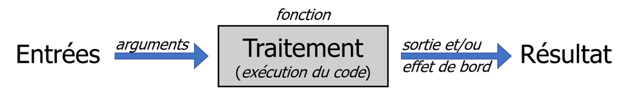

Schéma général d’une fonction

## 10.1 Principe des fonctions

On utilise les *fonctions* pour effectuer des calculs, obtenir des résultats et accomplir des actions.

Une fonction a un *nom*, elle prend en entrée entre parenthèses un ou plusieurs *arguments* (ou *paramètres*), et peut fournir une valeur en retour (paramètre de sortie ou *résultat*). Elle se termine souvent par la fonction `return()`.

Une fonction correspond à un regroupement d’instructions dans le but de réaliser une action précise et qui a vocation à être réutilisé.

On peut se demander dans quels cas il est utile de créer une fonction.

Une règle courante considère que dès qu’on a répété le même code plus de deux fois, il est préférable de l’encapsuler dans une fonction. Celles-ci ont en effet comme avantage d’éviter la duplication du code.

Cela permet d’éviter la redondance et d’améliorer la maintenabilité du code. En effet, si on a besoin de modifier le code, il suffit de le faire une seule fois dans la fonction, et non pas à chaque endroit où le code est dupliqué.

La fonction est un objet comme les autres, qu’on crée avec l’opérateur d’affectation.

Pour appliquer une fonction à un objet, la syntaxe est :

```r
nom_de_la_fonction(objet, attribut1, attribut2, ...)
```

Pour stocker le résultat de cette fonction dans une variable :

```r
ma_variable <- nom_de_la_fonction(objet, attribut1, attribut2, ...)
```

Une fonction est créée en utilisant l’instruction `function`. Celle-ci est suivie d’une paire de parenthèses et d’une paire d’accolades.

```r
function() {

}
```

La syntaxe générale d’une fonction est la suivante :

```r
nom_de_la_fonction <- function(parametre1, parametre2, ...) {
  # Corps de la fonction : ensemble d'instructions à exécuter
  # ...

  # La fonction peut retourner une valeur à l'appelant (ou NULL si aucune valeur n'est spécifiée)
  # return facultatif. Certains considèrent que l'ajouter permet de rendre le code plus lisible.
  return(resultat)
}
```

### 10.1.1 Paramètres (ou arguments) d’une fonction

Les **parenthèses** servent à indiquer les *paramètres* (ou *arguments*) de la fonction, ceux qui devront lui être passés lors de l’appel de la fonction.

Une fonction peut prendre plusieurs arguments. Dans ce cas on liste les arguments dans les parenthèses en les séparant par des virgules.

Une fonction peut aussi n’accepter aucun argument, dans ce cas on laisse les parenthèses vides.

Pour déterminer les paramètres à mettre dans la fonction, on cherche les éléments qui changent d’une utilisation à l’autre. Ces éléments variables deviendront ainsi les paramètres (ou arguments) de la fonction.

Les arguments des fonctions peuvent potentiellement être n’importe quel objet R. En particulier, certaines fonctions peuvent accepter des fonctions en argument.

```r
# La fonction "map" de purrr prend une fonction en argument
purrr::map(\(x) mean(x, na.rm = TRUE))

# C'est également le cas de "across" de dplyr
starwars |>
  summarise(across(c(height, mass), function(x) mean(x, na.rm = TRUE)))
```

#### 10.1.1.1 Valeurs par défaut

Il est possible de spécifier des **valeurs par défaut** pour les arguments lors de la définition d’une fonction. Ces valeurs seront utilisées si aucune valeur n’est renseignée lors de l’appel de la fonction. Pour renseigner une valeur par défaut, la syntaxe suivante peut être utilisée :

```r
f <- function(argument = valeur_defaut) {
  # Corps de la fonction
}
```

Dans l’aide d’une fonction existante, on voit les paramètres qui ont une valeur par défaut dans la section Usage.

Si un argument n’a pas de valeur par défaut, il est *obligatoire* : si l’utilisateur essaye d’appeler la fonction sans définir cet argument, cela génère une erreur.

Si à l’inverse un argument a une valeur par défaut, il devient *facultatif* : on peut utiliser la fonction sans préciser de valeur pour ce paramètre.

Lors de la définition d’une fonction, il vaut mieux placer les arguments avec une valeur par défaut en dernier :  
de cette façon, il est plus facile de ne pas les nommer, et il sera possible d’appeler la fonction sans préciser de valeur pour ces arguments.

```r
# Exemple de fonction prenant deux arguments, dont un avec une valeur par défaut
ma_fonction <- function(arg1, arg2 = 2020) {
  print(arg1)
  print(arg2)
}

# Appel de la fonction
ma_fonction(5) # arg1 vaut 5, arg2 vaut 2020
ma_fonction(5, 2010) # arg1 vaut 5, arg2 vaut 2010
```

#### 10.1.1.2 Nombre variable d’arguments

Il est possible de créer des fonctions qui acceptent un nombre variable d’arguments, ce qui les rend flexibles et adaptables à différentes situations. Cette fonctionnalité est souvent utilisée lorsque nous ne savons pas à l’avance combien d’arguments nous devrons passer à une fonction.

Pour ce faire, on utilise l’opérateur `...` comme argument de la fonction. Par ailleurs, il est d’usage de transformer les arguments fournis en liste dans le corps de la fonction pour que les arguments soient traités par la fonction.  
On utilise alors la commande `arguments <- list(...)`.

```r
# Exemple de fonction acceptant un nombre variable d’arguments
ma_fonction <- function(...) {
  arguments <- list(...)
  print(arguments)
}

# Appel de la fonction
ma_fonction(5, 2010, "texte")
```

```r
# Exemple de fonction acceptant un nombre variable d’arguments
calculer_somme_personnes_departements <- function(data, ...) {
  # Les arguments passés à la fonction sont stockés dans la variable arguments
  arguments <- list(...)

  # Filtrer le dataframe en fonction des départements spécifiés
  data_filtre <- data |>
    filter(libgeo %in% arguments)

  # Calculer la somme du nombre de personnes
  somme_personnes <- data_filtre |>
    summarise(nb_personnes_total = sum(nombre_personnes))

  # Renvoyer la somme calculée
  return(somme_personnes |>
            pull(nb_personnes_total))
}

# Appel de la fonction
calculer_somme_personnes_departements(revenus_dep, "Mayenne", "Sarthe")
```

### 10.1.2 Corps d’une fonction

Les **accolades** contiennent les instructions qui seront exécutées lorsque la fonction est appelée. Les accolades comprennent une série d’instructions R qui constituent le *corps* de la fonction. C’est ce code qui sera exécuté à l’appel de la fonction.  
On utilise dans le corps de la fonction les arguments qui lui sont passés (renseignés dans les parenthèses lors de l’appel de la fonction).

### 10.1.3 Résultat d’une fonction

Le plus souvent, pour qu’elle soit utile, la fonction doit renvoyer un résultat. Ceci se fait via l’instruction `return` à qui on passe la valeur à retourner.

En réalité, l’utilisation de `return()` n’est pas obligatoire : une fonction retourne automatiquement le résultat de la dernière instruction qu’elle exécute. Mais certains considèrent qu’il est souvent préférable de l’utiliser pour rendre le code plus lisible.

Lorsque R rencontre une instruction `return()` dans une fonction, il interrompt immédiatement son exécution et “sort” de la fonction en renvoyant le résultat.

#### 10.1.3.1 Résultat sous forme d’une liste

On ne peut pas utiliser plusieurs `return()` pour renvoyer plusieurs résultats depuis une seule fonction. L’exécution d’une fonction s’arrête au premier return rencontré.

Est-ce à dire qu’une fonction R ne pourrait renvoyer qu’une seule valeur ? Non, car si elle ne peut retourner qu’un seul objet, celui-ci peut être complexe et comporter plusieurs valeurs.

L’instruction `return()` ne peut renvoyer qu’un seul objet.  
Pour renvoyer plusieurs éléments dans une fonction, il faut les placer dans une liste.

Exemple avec une fonction nommée `indicateurs()`, où on retourne une liste contenant la moyenne et l’écart-type d’un vecteur :

```r
indicateurs <- function(v) {
  moyenne <- mean(v)
  ecart_type <- sd(v)

  resultat <- list(moyenne = moyenne, ecart_type = ecart_type)

  # return facultatif. Certains considèrent que l'ajouter permet de rendre le code plus lisible.
  return(resultat)
}
```

```r
indicateurs(hdv2003$age)
```

```
#> $moyenne
#> [1] 48.157
#>
#> $ecart_type
#> [1] 16.94181
```

On a du coup un affichage lisible, et on peut accéder aux éléments du résultat via leur nom :

```r
res <- indicateurs(hdv2003$age)
res$moyenne
```

```
#> [1] 48.157
```

### 10.1.4 Nommer une fonction

Enfin, pour que la fonction puisse être appelée et utilisée, il convient de lui donner un nom, ou plus précisément de la stocker dans un objet.

Le choix du nom de la fonction doit refléter clairement son objectif.

Un bon nom de fonction devrait :

- Décrire précisément l’action réalisée par la fonction
- Utiliser généralement un verbe d’action
- Être suffisamment explicite pour comprendre le rôle de la fonction sans avoir à lire son code

Par exemple : calculer_somme() ; convertir_en_majuscules()

```r
# Exemple du calcul de l'IMC
calcul_IMC <- function (poids, taille) {
  # La taille est exprimée en mètres
  imc <- poids / taille ^ 2

  # return facultatif. Certains considèrent que l'ajouter permet de rendre le code plus lisible.
  return(imc)
}

# Appel de la fonction
# On l’utilise en tapant son nom suivi de la valeur de ses arguments entre parenthèses
calcul_IMC(poids = 80, taille = 1.89)
calcul_IMC(poids = 60, taille = 1.55)
```

Une fonction se définit donc de la manière suivante :

[figure not shown]

## 10.2 Appel d’une fonction

```r
ma_fonction <- function(arg1, arg2, arg3) {
  print(arg1)
  print(arg2)
  print(arg3)
}
```

Lors de l’appel de la fonction, on peut lui passer les arguments *par position* :

```r
ma_fonction(x, 12, TRUE)
```

Dans ce cas, `arg1` vaudra `x`, `arg2` vaudra `12` et `arg3` vaudra `TRUE`.

On peut aussi passer les arguments *par nom* :

```r
ma_fonction(arg1 = x, arg2 = 12, arg3 = TRUE)
```

## 10.3 Exemples de fonctions

Identifier et écrire une fonction en suivant plusieurs étapes :

Étape 1 : repérer un bloc de code qui se répète => bloc d’instructions de la fonction. Le *corps* de la fonction, situé à l’intérieur d’un bloc `{}`, est la partie de la fonction qui permet d’appliquer les manipulations voulues pour obtenir le résultat à retourner.  
On peut commencer par réaliser une instruction simple sur quelques données. Une fois que ça fonctionne pour un élément, il sera plus simple de généraliser.

Étape 2 : identifier ce que sera l’entrée de la fonction

Étape 3 : identifier ce qui varie dans le code => arguments (éléments *variables*) de la fonction (avec ou sans valeur par défaut). Il peut s’agir de l’objet qui sera transformé par la fonction (par exemple un dataframe) ou d’un paramètre utilisé dans la fonction (par exemple un entier).

Étape 4 : définir ce que renvoie la fonction (sortie de la fonction) => dernier objet ou objet retourné par return(). En effet, return est facultatif. Certains considèrent que l’ajouter permet de rendre le code plus lisible.

Étape 5 : définir ce que fait la fonction => nom de la fonction. On conseille de donner un verbe comme nom de fonction (par exemple calculer_moyenne, renommer_colonnes).

Étape 6 : tester et vérifier la fonction

Une fonction personnelle s’utilise comme n’importe quelle autre fonction de R. On l’appelle en tapant son nom suivi de la valeur de ses arguments entre parenthèses.  
Notamment, on récupère la sortie de la fonction en **affectant le résultat à un objet**  
⇒ sinon il n’y aura que l’affichage dans la console.

Une bonne façon d’écrire des fonctions efficaces est d’écrire des **fonctions courtes**.  
Idéalement, une fonction fait **une et une seule** chose. Ainsi, il est plus facile de :

```
Comprendre ce que fait chaque fonction

Insérer et réutiliser les fonctions à de multiples endroits

Maintenir le code et en particulier modifier des aspects du traitement
```

```r
library(dplyr)
library(tidyr)
library(janitor) # pour round_half_up

# fonction secteurs
secteur_1 <- function(df) {
  df |>
    select(region, '2019', '2020') |>
    filter(region %in% c("France métropolitaine", "Pays de la Loire"))
}

# nouvelle variable emploi_salarie en mettant la liste des especes par transposition
secteur_2 <- function(df) {
  df |>
    pivot_longer(cols = c('2019', '2020'),
                 names_to = c("annee"),
                 values_to = "nb_emploi_salarie")
}

# utilisation fonction secteur
b_iaa <- secteur_1(b_iaa)
# ajout colonne secteur
b_iaa_long <- secteur_2(b_iaa) |>
  mutate(secteur = "b2_iaa")
```

```r
# fonction pour an_semestre en colonne
an_sem_col <- function(df) {
  df |>
    pivot_wider( names_from = c(annee,semestre),
                 names_prefix="an_",
                 values_from = montant)
}

# utilisation fonction pour an_semestre en colonne
produits_AZ_C1_reg <- an_sem_col(produits_long_AZ_C1_reg)
```

```r
# fonction pour calcul évolutions et / semestre précédent
calcul_evol <- function(df) {
   df |>
      mutate(diff2022_sem1_evol = an_2022_sem1 - an_2021_sem1,
             diff2022_sem1_evol_perc = (an_2022_sem1 / an_2021_sem1 -1) * 100,
             diff2021_sem2_evol_prec = an_2021_sem2-an_2021_sem1,
             diff2021_sem2_evol_prec_perc = (an_2021_sem2 / an_2021_sem1 -1) * 100,
             diff2022_sem1_evol_prec = an_2022_sem1-an_2021_sem2,
             diff2022_sem1_evol_prec_perc = (an_2022_sem1 / an_2021_sem2 -1) * 100
             )
}

# utilisation fonction calcul évolutions
produits_AZ_C1_reg <- calcul_evol(produits_AZ_C1_reg)
```

```r
# pour calculer le ratio entre la production de PDL (eff_aaaa_pdl) et la production FM (eff_aaaa_fm).
# on crée une nouvelle colonne pour chaque colonne qui commence par "eff_" et finit par "_pdl"
# La fonction est définie avec \(x)
# x représente les données de la colonne courante
# La valeur de cette colonne est calculée en divisant la valeur de colonne actuelle (x)
# par la valeur d'une autre colonne.
# Le nom de cette autre colonne est obtenu en remplaçant "_pdl" par "_fm"
# dans le nom de la colonne actuelle (cur_column()).
# cur_column() donne le nom de la colonne actuelle (uniquement dans across())
# get est utilisé pour obtenir le contenu de cette autre colonne (le dénominateur) à partir de son nom.
# Le résultat est multiplié par 100 pour obtenir un pourcentage.
# La fonction .names est utilisée pour renommer les nouvelles colonnes
# en ajoutant le préfixe part_ avant le nom de la colonne originale.
# .col représente le nom de la colonne courante
# ne pas oublier le point dans .col
# .names = "part_{.col}" : Ceci spécifie le format du nom de la nouvelle colonne.
# {.col} est remplacé par le nom de la colonne actuelle.
# Par exemple, si la colonne actuelle est "eff_2000_pdl", le nom de la nouvelle colonne sera "part_eff_2000_pdl".
eff_volailles_annee_part <- eff_volailles_annee |>
  pivot_wider(names_from = reg_court,
              values_from = contains("eff"),
              names_prefix = "") |>
  # fonction pour calcul_part_pdl
  mutate(across(
    matches("eff_.*_pdl"),
    \(x) {
      fm_col <- str_replace(cur_column(), "_pdl", "_fm")
      x / get(fm_col) * 100
    },
    .names = "part_{.col}")) |>
  relocate(starts_with("part_"), .after = espece)

eff_volailles_annee_part <- eff_volailles_annee_part |>
  mutate(across(starts_with("part_"), \(x) round_half_up(x, digits = 2))) |>
  arrange(espece)
```

```r
# cas de plusieurs modalités par variable
# traitement récurrent
# fonction pour effectuer la transformation des données dep + reg
transform_data <- function(data_entree) {
  data_dep_1 <- data_entree |>
    select(-contains("reg")) |>
    pivot_longer(cols = contains("_dep"),
                 names_to = "indicateur",
                 values_to = "donnees_dep",
                 names_pattern = "(.*)_dep")

  data_dep_2 <- data_dep_1 |>
    pivot_wider(names_from = depart,
                values_from = donnees_dep)

  data_reg <- data_entree |>
    select(-contains("dep")) |>
    pivot_longer(cols = contains("_reg"),
                 names_to = "indicateur",
                 values_to = "ensemble",
                 names_pattern = "(.*)_reg") |>
    distinct()

  # regroupement dep reg avec left_join
  agreg_data_dep_reg <- data_dep_2 |>
    left_join(data_reg,
                join_by(indicateur, modalites))

  # return facultatif. Certains considèrent que l'ajouter permet de rendre le code plus lisible.
  return(agreg_data_dep_reg)
}

# utilisation de la fonction transform_data
agreg_tr_surf_logt_vol_chair_grand_dep_reg_2 <- transform_data(data_entree = agreg_tr_surf_logt_vol_chair_grand)
```

```r
# Définition d'un opérateur `%not_in%` pour plus de clarté dans les filtres
`%not_in%` <- purrr::negate(`%in%`)

# on utilise un paramètre negate pour inverser la logique de filtrage
# le paramètre negate inverse une condition logique avec !
# booléen qui détermine si on souhaite appliquer la logique normale ou inversée pour filtrer les données.
# on utilise la négation de %in% pour le total des volailles
# équivalent pour la ligne : produit %not_in% c("Ensemble gallus","Lapines reproductrices") ~ "12_Total_volailles",
# purrr::negate(`%in%`) : crée une nouvelle fonction qui inverse le résultat d'une fonction existante
process_data_avant_2010 <- function(data, filter_espece, espece_modalite, negate = FALSE) {
  result <- data |>
    mutate(
      espece = case_when(
        # Si negate est FALSE et produit est dans filter_espece,
        # alors espece prend la valeur espece_modalite
        negate == FALSE & produit %in% filter_espece ~ espece_modalite,

        # Si negate est TRUE et produit n'est pas dans filter_espece,
        # alors espece prend la valeur espece_modalite
        negate == TRUE & !(produit %in% filter_espece) ~ espece_modalite,

        # Dans tous les autres cas, espece prend la valeur produit
        .default = produit
      )
    ) |>
    # Filtrage pour inclure uniquement les valeurs de espece_modalite
    filter(espece %in% espece_modalite) |>
    group_by(reg_court, annee, espece) |>
    mutate(valeur_pdl = sum(valeur)) |>
    arrange(reg_court, annee, espece) |>
    ungroup() |>
    group_by(annee, espece) |>
    mutate(valeur_fm = sum(valeur)) |>
    arrange(annee, espece) |>
    ungroup() |>
    filter(reg_court == "pdl") |>
    select(-c(reg, reg_court, produit, valeur)) |>
    distinct()

  # return facultatif. Certains considèrent que l'ajouter permet de rendre le code plus lisible.
  return(result)
}

# Application de la fonction pour chaque cas
# Cas standard (negate = FALSE, par défaut)
# produit %in% filter_espece ~ espece_modalite
# Sélectionne les produits qui sont dans filter_espece
# Exemple : "Canards à gaver" ET "Canards à rôtir" → "06_07_canards_cheptel"
eff_volailles_avant_2010_regroupt_1 <- process_data_avant_2010(data = eff_volailles_avant_2010,
                                           filter_espece = c("Canards à gaver", "Canards à rôtir"),
                                           espece_modalite = "06_07_canards_cheptel")

eff_volailles_avant_2010_regroupt_2 <- process_data_avant_2010(eff_volailles_avant_2010,
                                           filter_espece = c("Poules pondeuses d'oeufs à couver",
                                                            "Poules pondeuses d'oeufs de consommation"),
                                           espece_modalite = "01_02_Poules_pondeuses")

# Cas inversé (negate = TRUE)
# !(produit %in% filter_espece) ~ espece_modalite
# Sélectionne les produits qui NE SONT PAS dans filter_espece
# Équivalent à produit %not_in% filter_espece
# pour la ligne : produit %not_in% c("Ensemble gallus","Lapines reproductrices") ~ "12_Total_volailles",
# Exemple : Tout SAUF "Ensemble gallus" et "Lapines reproductrices" → "12_Total_volailles"
eff_volailles_avant_2010_regroupt_3 <- process_data_avant_2010(eff_volailles_avant_2010,
                                                  filter_espece = c("Ensemble gallus", "Lapines reproductrices"),
                                                  espece_modalite = "12_Total_volailles",
                                                  negate = TRUE)

# Combinaison des résultats
eff_volailles_avant_2010_3 <- bind_rows(eff_volailles_avant_2010_2,
                                        eff_volailles_avant_2010_regroupt_1,
                                        eff_volailles_avant_2010_regroupt_2,
                                        eff_volailles_avant_2010_regroupt_3)
```

## 10.4 Portée des variables

Un objet créé dans une fonction n’existe que dans cette fonction.

Un objet créé à l’intérieur d’une fonction est temporaire et n’est pas accessible à l’extérieur de celle-ci.

```r
f <- function() {
  nouvel_objet <- 15
  nouvel_objet
}

f()
```

```
#> [1] 15
```

```r
nouvel_objet
```

```
#> Error: object 'nouvel_objet' not found
```

Ici, `nouvel_objet` existe tant qu’on est dans la fonction, mais il est détruit dès qu’on en sort et donc inaccessible dans l’environnement global.

Les objets créés dans la session courante et qui existent dans l’environnement (visible dans l’onglet *Environment* de RStudio) sont appelés des **objets globaux** : ils existent et sont accessibles pour les fonctions appelées depuis cet environnement.

Les objets créés lors de l’exécution d’une fonction sont à l’inverse des **objets locaux** : ils n’existent qu’à l’intérieur de la fonction et pour la durée de son exécution. Les variables locales ont une portée limitée à une fonction ou à un environnement spécifique. Elles existent dans des environnements à portée limitée (comme un environnement d’exécution).  
Les variables locales sont par exemple les arguments d’une fonction ou les variables définies à l’intérieur d’une fonction.

Si deux objets du même nom coexistent, l’objet local est prioritaire par rapport à l’objet global.

Si on souhaite modifier un objet global, on doit le passer comme argument en entrée de la fonction, et le renvoyer comme résultat en sortie. Pour que le recodage soit bien répercuté dans le tableau `df`, on doit faire :

```r
recode_taille <- function(d) {
  d$taille <- d$taille / 100

  return(d)
}

df <- recode_taille(df)

# Le recodage est bien conservé
```

## 10.5 Les conditions `if`, `else`

Les commandes `if` et `else` sont utilisables pour exécuter du code sous certaines conditions.  
Cela permet de réaliser ainsi une exécution conditionnelle.  
Le “then” n’existe pas : il est implicite après les accolades.

Ainsi, une série d’instructions ne sera exécutée que dans certins cas. Par exemple, on va pouvoir exécuter certaines instructions selon la valeur prise par les arguments de la fonction.

### 10.5.1 `if`

L’instruction `if` permet de n’exécuter du code que si une condition est remplie.

`if` est suivie d’une condition (entre parenthèses) puis d’un bloc de code (entre accolades). Ce bloc de code n’est exécuté que si la condition est vraie.

[figure not shown]

Une utilisation possible dans le cadre d’une fonction est de n’exécuter certaines instructions que si la valeur d’un argument vaut une valeur donnée. Dans l’exemple suivant, on n’applique la fonction `round()` que si l’argument `arrondir` vaut `TRUE`.

```r
moyenne <- function(x, arrondir = TRUE) {
    res <- mean(x)
    if (arrondir == TRUE) {
        res <- round(res)
    }
    res
}

v <- c(1.4, 2.3, 8.9)
moyenne(v)
moyenne(v, arrondir = FALSE)
```

On notera que le test `x == TRUE` est en fait redondant, car son résultat est le même que la valeur de `x` :

- si `x` vaut `TRUE`, `x == TRUE` vaut `TRUE`
- si `x` vaut `FALSE`, `x == TRUE` vaut `FALSE`

On remplacera donc en général `if (x == TRUE)` par `if (x)`.

De la même manière, on pourra remplacer `if (x == FALSE)` par `if (!x)`.

Dans la fonction `moyenne` ci-dessus, on peut donc remplacer :

```r
if (arrondir == TRUE) {
    res <- round(res)
}
```

Par :

```r
if (arrondir) {
    res <- round(res)
}
```

À noter également que quand le bloc de code qui suit une instruction `if` ne comporte qu’une seule instruction, on peut omettre les accolades qui l’entourent. Les syntaxe suivantes sont donc équivalentes :

```r
if (arrondir) {
    res <- round(res)
}

if (arrondir) res <- round(res)
```

### 10.5.2 `if` / `else`

`else` permet d’exécuter des instructions lorsque la condition donnée au `if` n’est pas remplie.

`else` s’utilise après `if`, mais n’est pas obligatoire.

`else` précède un autre bloc de code R qui ne s’exécute que si la condition donnée au `if` est fausse :

[figure not shown]

On peut ainsi utiliser `if` / `else` pour effectuer deux actions différentes en fonction de la valeur d’un argument. La fonction suivante génère deux graphiques différents selon le type du vecteur passé en argument :

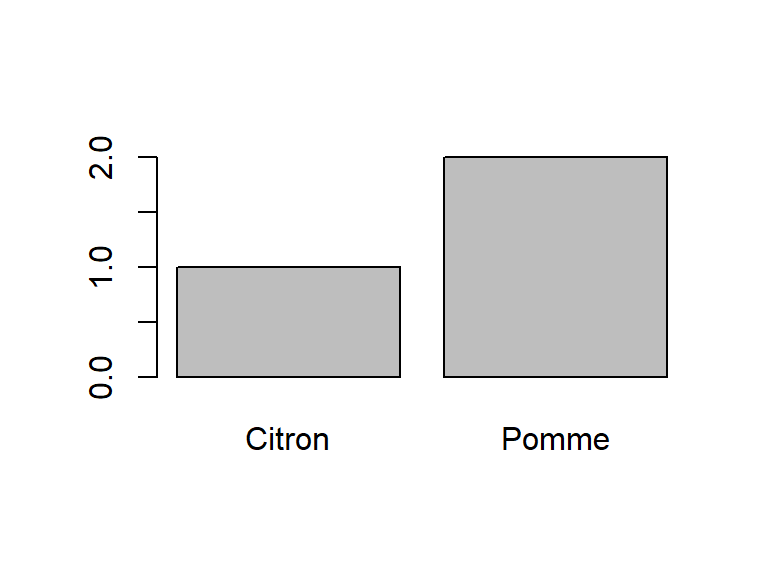

```r
graph_var <- function(x) {
    if (is.character(x)) {
        barplot(table(x))
    } else {
        hist(x)
    }
}

graph_var(c("Pomme", "Pomme", "Citron"))
```

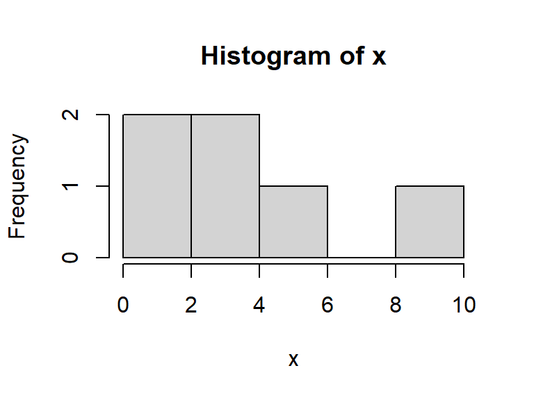

```r
graph_var(c(1, 5, 10, 3, 1, 4))
```

### 10.5.3 `if` / `else if` / `else`

On peut enchaîner plusieurs blocs d’instructions `if` / `else if` / `else`.

Une possibilité complémentaire est d’ajouter des blocs `else if` qui permettent d’ajouter des conditions supplémentaires. Dès qu’une condition est vraie, le bloc de code correspondant est exécuté. Le dernier bloc `else` est exécuté si aucune des conditions n’est vraie.

On peut donc améliorer encore la fonction `graph_var()` pour tester plusieurs types explicitement et afficher un message si aucun type géré n’a été reconnu.

```r
graph_var <- function(x) {
    if (is.character(x)) {
        barplot(table(x))
    } else if (is.numeric(x)) {
        hist(x)
    } else {
        message("Le type de x n'est pas géré par la fonction")
    }
}

graph_var(c(TRUE, FALSE, TRUE))
```

Attention, seul le bloc de la première condition vraie est exécuté, l’ordre des conditions est donc important. Dans l’exemple suivant, le second bloc n’est jamais exécuté et donc le second message jamais affiché.

```r
test_x <- function(x) {
    if (x < 100) {
        message("x est inférieur à 100")
    } else if (x < 10) {
        message("x est inférieur à 10")
    }
}

test_x(5)
```

Il est donc important d’ordonner les conditions de la plus spécifique à la plus générale.

### 10.5.4 Construction de conditions complexes

On peut combiner plusieurs tests avec les opérateurs logiques classiques :

- `!` est l’opérateur “not”, qui teste si la condition qu’il précède est fausse
- `&&` est l’opérateur “et”, qui est vrai si les deux conditions qu’il réunit sont vraies
- `||` est l’opérateur “ou inclusif”, qui est vrai si au moins l’une des deux conditions qu’il réunit sont vraies
- `xor` est l’opérateur “ou exclusif”, qui retourne TRUE si l’une ou l’autre des propositions est vraie, pas les deux

Ainsi, si on veut qu’une variable `temperature` soit comprise entre 15 et 25, on écrira :

```r
verifie_temperature <- function(temperature) {
    if (temperature >= 15 && temperature <= 25) {
        message("Température ok")
    }
}
verifie_temperature(20)
```

Si on souhaite tester que `temperature` est inférieure à 15 ou supérieure à 25 :

```r
verifie_temperature <- function(temperature) {
    if (temperature < 15 || temperature > 25) {
        message("Température pas cool")
    }
}
verifie_temperature(10)
```

Si on veut tester si `temperature` vaut `NULL`, on peut utiliser `is.null()`.

```r
verifie_temperature <- function(temperature = NULL) {
    if (is.null(temperature)) {
        message("Merci d'indiquer une température")
    }
}
verifie_temperature()
```

Mais si à l’inverse on veut tester si `temperature` *n’est pas* `NULL`, on inverse le test précédent en utilisant `!`.

```r
verifie_temperature <- function(temperature = NULL) {
    if (!is.null(temperature)) {
        message("Merci d'avoir indiqué une température")
    }
}
verifie_temperature(15)
```

On pourra noter qu’il existe deux types d’opérateurs “et” et “ou” dans R :

- Les opérateurs simples `&` et `|` sont des opérateurs *vectorisés*. Ils peuvent s’appliquer à des vecteurs et retourneront un vecteur de `TRUE` et `FALSE`.
- Les opérateurs doubles `&&` et `||` ne peuvent retourner qu’une seule valeur, et si on leur fournit des vecteurs ils génèrent une erreur.

```r
x <- 1:5
x > 0 & x <= 2
```

```r
x > 0 && x <= 2
```

Quand on passe un test à un `if`, celui-ci est censé retourner une unique valeur `TRUE` ou `FALSE`. Une erreur fréquente, notamment quand on est dans une fonction, est de passer à `if` une condition appliquée à un vecteur. Dans ce cas R affiche une erreur.

```r
superieur_a_5 <- function(x) {
    if (x >= 5) {
        message(">=5")
    }
}

superieur_a_5(1:10)
```

```
## Error in if (x >= 5) {: la condition est de longueur > 1
```

À retenir : quand on utilise l’instruction `if`, la condition qui lui est passée entre parenthèses ne doit renvoyer qu’une seule valeur `TRUE` ou `FALSE`. Si on utilise une condition complexe, on utilisera donc plutôt les opérateurs doubles `&&` et `||`.

### 10.5.5 Différence entre `if` / `else` et `if_else`

Une source fréquente de confusion concerne la différence entre les instructions `if` / `else` et la fonction `if_else()` de `dplyr`. Les deux sont pourtant très différentes :

- `if` / `else` s’utilisent quand on teste une seule condition et qu’on veut exécuter des blocs de code différents selon son résultat
- `if_else` applique un test à tous les éléments d’un vecteur et retournent un vecteur dont les éléments dépendent du résultat de chaque test

Premier cas de figure : un objet `x` contient une seule valeur et on veut afficher un message différent selon si celle-ci est inférieure ou supérieure à 10. Dans ce cas on utilise `if` / `else`.

```r
x <- 5

if (x >= 10) {
    message(">=10")
} else {
    message("<10")
}
```

Deuxième cas de figure : `x` est un vecteur et on souhaite recoder chacune de ses valeurs selon le même critère que ci-dessus. Dans ce cas on utilise `if_else`.

```r
x <- 5:15
x_rec <- if_else(x >= 10, ">=10", "<10")
x_rec
```

Exemple de fonction avec `if` / `else`

```r
# fonction montants par departement pour les différentes années ----
# Fonction pour calculer les montants par département
# Paramètre annee : la fonction prend en entrée l'année pour laquelle on souhaite effectuer les calculs.
# La fonction glue() permet d’insérer des variables et des expressions directement dans des chaînes de caractères
# Cela permet d’évaluer dynamiquement les expressions à l’intérieur des accolades {}
calculer_montants_par_departement <- function(annee) {
  # Utilisation de substr() pour extraire les deux derniers chiffres de l'année
  an <- substr(as.character(annee), 3, 4)
  # Construire les noms de fichiers et les chemins
  # Les noms de fichiers sont stockés dans des variables qui ont des noms dynamiques,
  # c'est-à-dire que les noms de ces variables dépendent de la valeur de 'annee'.
  # Les noms des fichiers sont construits dynamiquement en fonction de l'année passée en paramètre.
  # Pour accéder à la valeur de la variable dont le nom est contenu dans une chaîne de caractères,
  # on utilise `get` (pour interpréter cette chaîne comme le nom d'une variable et accéder à sa valeur).
  # get permet d'évaluer une chaîne de caractères comme un nom de variable
  # et de récupérer la valeur associée à ce nom de variable
  # get() prend cette chaîne de caractères et recherche une variable avec ce nom dans l'environnement actuel.
  # get() prend en entrée une chaîne de caractères représentant le nom d'un objet et retourne cet objet
  # Dans notre cas, la chaîne de caractères est le nom du fichier à charger.
  # get() va donc chercher dans l'environnement global l'objet ayant ce nom et le renvoyer.
  fichier_beneficiaires <- get(glue("fichier_beneficiaires_{annee}"))
  fichier_paiements_p1 <- get(glue("fichier_paiements_p1_{annee}"))
  fichier_paiements_ichn_aras <- get(paste0("fichier_paiements_ichn_aras_", annee))
  fichier_paiements_bio_maec <- get(paste0("fichier_paiements_bio_maec_", annee))

  # Construire la partie dynamique du chemin
  chemin_pac_annee <- get(glue("pac_{annee}"))

  # Construire le chemin complet
  chemin_fichier_benef <- glue("{chemin_aides_pac}{chemin_pac_annee}{fichier_beneficiaires}")
  chemin_fichier_paiements_p1 <- glue("{chemin_aides_pac}{chemin_pac_annee}{fichier_paiements_p1}")
  chemin_fichier_paiements_ichn_aras <- glue("{chemin_aides_pac}{chemin_pac_annee}{fichier_paiements_ichn_aras}")
  chemin_fichier_paiements_bio_maec <- glue("{chemin_aides_pac}{chemin_pac_annee}{fichier_paiements_bio_maec}")

  # Lecture des fichiers
  fic_benef <- readRDS(file = chemin_fichier_benef) |>
    as_tibble(.name_repair = make_clean_names) |>
    filter(nreg == "52")

  fic_paiements_p1 <- readRDS(file = chemin_fichier_paiements_p1) |>
    as_tibble(.name_repair = make_clean_names)

  fic_paiements_ichn_aras <- readRDS(file = chemin_fichier_paiements_ichn_aras) |>
    as_tibble(.name_repair = make_clean_names)

  fic_fichier_paiements_bio_maec <- readRDS(file = chemin_fichier_paiements_bio_maec) |>
    as_tibble(.name_repair = make_clean_names)

  # Jointure des fichiers et calcul des montants par département
  # on remplace les années fixes par le paramètre 'annee' (4 positions) ou 'an' (2 positions)
  # Pour accéder aux colonnes de manière dynamique (accéder aux données des variables dynamiques)
  # Si un argument est un nom de colonne passé sous la forme d’une chaîne de caractères ("variable"),
  # on y accède avec le pronom .data et l’opérateur double crochet, soit .data[["variable"]]
  # .data est un pronom qui fait référence au dataframe en cours de traitement.
  # [[]] est utilisé pour accéder à une colonne par son nom (en utilisant une chaîne de caractères).
  # NA_real_: spécifiquement pour les valeurs manquantes de type numérique
  montants_pdl <- fic_benef |>
    left_join(fic_paiements_p1, join_by(pacage))
    left_join(fic_paiements_ichn_aras, join_by(pacage)) |>
    left_join(fic_fichier_paiements_bio_maec, join_by(pacage)) |>
    group_by(dep) |>
    summarise(
      montant_aide_1er_pilier = sum(.data[[paste0("aides_p1_", an)]] / 1000, na.rm = TRUE),
      montant_aide_decouplee = sum(.data[[paste0("pu_", an)]] / 1000, na.rm = TRUE),
      dont_paiement_de_base = sum(.data[[paste0("pbase_", an)]] / 1000, na.rm = TRUE),
      dont_paiement_vert = if (an == "23") {
        NA_real_
      } else {
        sum(.data[[paste0("pvert_", an)]] / 1000, na.rm = TRUE)
      }, # n'existe plus en 2023
      dont_paiement_ecoregime = if (an == 23) {
        sum(.data[[paste0("pecor_", an)]] / 1000, na.rm = TRUE)
      } else {
        NA_real_
      }, # Nouvelle aide PAC 2023
      montant_aides_couplees_animales = sum(.data[[paste0("aca_", an)]] / 1000, na.rm = TRUE),
      dont_aide_aux_bovins_totale_post_2023 = if (an == 23) {
        sum(.data[[paste0("ab_", an)]] / 1000, na.rm = TRUE)
      } else {
        NA_real_
      }, # Nouvelle aide PAC 2023
      dont_aide_aux_bovins_totale = if (an == 23) {
        NA_real_
      } else {
        sum((.data[[paste0("aba_", an)]] +
               .data[[paste0("vm_", an)]] +
               .data[[paste0("abl_", an)]]) / 1000, na.rm = TRUE)
      }, # n'existe plus en 2023
      montant_aide_totale = sum(montant_aide_1er_pilier,
                                montant_aide_2d_pilier,
                                na.rm = TRUE
      )
    ) |>
    ungroup() |>
    pivot_longer(-dep,
                 names_to = "indicateur",
                 values_to = "valeur"
    ) |>
    pivot_wider(names_from = "dep", values_from = "valeur")

  # Renommage des colonnes : Les colonnes sont renommées avec un suffixe correspondant à l'année.
  # ajout suffixe année aux noms de colonnes sauf pour la première colonne (indicateur)
  montants_pdl <- montants_pdl |>
    rename_with(
          \(x) paste0(x, "_", annee),
          -indicateur
          )

  # Retourner une liste contenant les dataframes
  return(list(
    fic_benef = fic_benef,
    fic_paiements_p1 = fic_paiements_p1,
    fic_paiements_ichn_aras = fic_paiements_ichn_aras,
    fic_fichier_paiements_bio_maec = fic_fichier_paiements_bio_maec,
    montants_pdl = montants_pdl
  ))
}

# Calculer les montants pour 2020...
montants_2020 <- calculer_montants_par_departement(annee = 2020)
montants_2021 <- calculer_montants_par_departement(annee = 2021)
montants_2022 <- calculer_montants_par_departement(annee = 2022)
montants_2023 <- calculer_montants_par_departement(annee = 2023)

# Pour accéder aux éléments de la liste :
beneficiaires_2020 <- montants_2020$fic_benef
beneficiaires_2021 <- montants_2021$fic_benef
paiements_p1_2020 <- montants_2020$fic_paiements_p1
paiements_p1_2021 <- montants_2021$fic_paiements_p1
montants_pac_2020 <- montants_2020$montants_pdl

# Combiner les resultats des différentes années
montants_pac_2020_2023 <- montants_pac_2020 |>
  left_join(montants_2021$montants_pdl, join_by(indicateur)) |>
  left_join(montants_2022$montants_pdl, join_by(indicateur)) |>
  left_join(montants_2023$montants_pdl, join_by(indicateur))
```

## 10.6 Les boucles `for` et `while` pour répéter des instructions

Les boucles permettent de répéter un traitement plusieurs fois, soit en fonction d’une condition soit selon les éléments d’un vecteur.

### 10.6.1 `for`

La boucle définie par l’instruction `for` permet de répéter une opération sur un ensemble de valeurs d’une séquence.  
Sa structure est la suivante :

[figure not shown]

Le principe est le suivant : on fournit à `for` entre parenthèses une expression du type `item in vecteur`, puis un bloc de code entre accolades. `for` va exécuter le bloc de codes pour chacune des valeurs de `vecteur`, et affectera tour à tour à `item` la valeur courante de `vecteur`.

Exemple de fonction

```r
diag_IMC <- function(poids,taille) {
  imc <- poids / taille ^ 2

  if (imc < 18.5) {diag <- "maigre"}
    else if (imc < 25) {diag <- "normal"}
       else {diag <- "surpoids"}

  # return facultatif. Certains considèrent que l'ajouter permet de rendre le code plus lisible.
  return(diag)
}

diag_IMC (poids = 60, taille = 1.89)
diag_IMC (poids = 80, taille = 1.89)
diag_IMC (poids = 80, taille = 1.55)
```

On peut utiliser une boucle `for` :

```r
for (pp in seq(from = 50, to = 100, by = 5)) {
  # print permet d'afficher des informations dans la console, comme cat
  print(paste ("Taille = 1,70m, poids =", pp, "Diagnotic :",
               diag_IMC (poids = pp, taille = 1.70)))
}
```

### 10.6.2 `while`

La boucle `while` permet de répéter une opération tant qu’une condition est vérifiée. `while` prend en argument une condition et est suivi d’un bloc de code entre accolades. Elle exécute le bloc tant que la condition est vraie :

[figure not shown]

Par exemple, la fonction suivante simule un tirage à pile ou face à l’aide de la fonction `sample()`. La simulation de tirage s’exécute et affiche le résultat tant qu’on obtient “Pile” (et interrompt la boucle au premier “Face”) :

```r
resultat <- "" # initialisation de la variable `resultat` avec une chaîne vide
while (resultat != "Face") {
    resultat <- sample(c("Pile", "Face"), size = 1)
    print(resultat)
}
```

```
[1] "Pile"
[1] "Pile"
[1] "Face"
```

### 10.6.3 Quand (ne pas) utiliser des boucles `for` et `while`

Le mécanisme des boucles, assez intuitif, peut être utilisé pour beaucoup d’opérations. Il y a cependant sous R des alternatives souvent plus rapides, qu’il est préférable de privilégier.

Avant tout, de nombreuses fonctions R sont “vectorisées” et s’appliquent directement à tous les éléments d’un vecteur. Dans le cas où une fonction vectorisée existe déjà, elle propose en général une syntaxe plus compacte et une exécution (beaucoup) plus rapide.

Par exemple, si on souhaite remplacer dans tous les éléments d’un vecteur de chaînes de caractères le caractère “X” par le caractère “o”, on pourrait être tenter de faire une boucle du type :

```r
mots <- c("brXuette", "mXtX", "iglXX")
for (i in seq_along(mots)) {
    mots[i] <- str_replace_all(mots[i], "X", "o")
}
```

Or c’est tout à fait inutile car `str_replace_all()` étant vectorisée, on peut l’appliquer directement à un vecteur sans utiliser de boucle.

```r
mots <- str_replace_all(mots, "X", "o")
```

Entre les fonctions vectorisées existantes et les possibilités fournies par `purrr`, il est assez rare de devoir utiliser une boucle directement dans R. Pour autant, il ne faut pas non plus tomber dans l’excès inverse et considérer que tout usage de `for` ou `while` doit être évité : ces fonctions sont parfaitement justifiées dans certains cas de figure, et si vous trouvez une solution qui fonctionne de manière efficace avec une boucle `for`, il n’est pas forcément utile de chercher à la remplacer.

## 10.7 Itérer avec `purrr`

Des fonctions tirées du package `purrr` permettent d’appliquer une même fonction à chaque élément d’une liste ou d’un vecteur.

`purrr` est une extension du *tidyverse* qui fournit des outils pour travailler avec les vecteurs et les fonctions, et notamment pour itérer sur les éléments de vecteurs ou de listes en leur appliquant une fonction.

### 10.7.1 Principe de`map` et ses variantes

L’objectif de `map` est d’appliquer une fonction à l’ensemble des éléments d’un vecteur ou d’une liste.  
La fonction `map()` de `purrr` prend deux arguments principaux :

1. un vecteur ou une liste d’entrée
2. une fonction

et elle retourne une liste contenant le résultat de la fonction appliquée à chaque élément du vecteur ou de la liste.

En résumé, Le traitement à effectuer correspond à une fonction à appliquer . On peut la renseigner de différentes façons :

- avec le nom de la fonction (sans parenthèses): lorsque la fonction n’a besoin **que d’un seul paramètre**, qui est l’élément courant à traiter  
  exemple map(…, mean)
- avec une fonction anonyme
  - définie avec la syntaxe concise `\(x)` et `x` : les éléments successifs de la liste sont alors identifiés avec `x`  
    exemple map(…, (x) x |> summarise(moyenne = mean(population))) exemple map(…, (x) read_csv2(x))
  - définie avec la syntaxe classique, avec function(x)  
    exemple map(…, function(x) read_csv2(x))  
    # ou avec un nom de paramètre plus explicite  
    exemple map(…, function(nom_fichier) read_csv2(nom_fichier)) map(…, function(x) { … })

    ```r
    map(fichiers, function(nom_fichier) {
      data <- read_csv2(nom_fichier)
      mutate(data, date = as.Date(date))  # Transformation supplémentaire
      })
    ```

`x` représente chaque élément courant à traiter (la place de la variable à traiter dans la fonction). `x` est une variable positionnelle qui représente l’élément courant. Les noms de paramètres dans `function(x)` peuvent être personnalisés pour améliorer la lisibilité du code.

```r
# 1. Lecture de fichiers CSV avec \(x)
donnees <- map(fichiers, \(f) read_csv2(f))

# 2. Nettoyage avec function(nom_param)
donnees_nettoyees <- map(donnees, function(df) {
  df |>
    filter(!is.na(id)) |>
    mutate(across(where(is.numeric),
           \(x) replace_na(x, 0)))
})

# 3. Résumé statistique avec \(x)
stats <- map(
  donnees_nettoyees,
  \(x) x |>
    summarise(
      across(
        where(is.numeric),
        list(mean = mean, somme = sum)
      )
    )
)
```

Les fonctions map renvoient des listes. On peut retrouver des data.frame plus faciles à manipuler en utilisant `bind_rows()`, ou la fonction `reduce()`.  
`bind_rows()` permet de concaténer une liste de tables, de combiner tous les résultats en un seul dataframe.  
`reduce()` permet de combiner les éléments d’une liste en un seul élément en appliquant une fonction de réduction.

`reduce()` applique une fonction de façon récursive à chaque élément d’une liste ou d’un vecteur

```r
# Création d'une liste des fichiers à traiter
donnees_RP <- c("donnees_RP2020.csv", "donnees_RP2015.csv", "donnees_RP2010.csv") |>
 map(read_delim,
     delim = ";", # séparateur point-virgule
     locale = locale(decimal_mark = ","), # virgule comme séparateur décimal
     col_types = cols(CODGEO = col_character(), .default = col_double())) |> # définit les types des colonnes
 reduce(full_join)
```

Dans cet exemple, on crée une liste de fichiers à traiter, puis on utilise `map()` pour lire chaque fichier avec `read_delim()`.

On utilise reduce(full_join) pour fusionner tous les fichiers en une seule table.

Après import, les trois fichiers sont joints les uns après les autres pour obtenir une seule table contenant toutes les informations.

### 10.7.2 Nommage des résultats

Par défaut, les différents éléments de la liste résultats ne sont pas nommés. On ne peut accéder aux différents éléments que par index (comme dans une liste classique).

La fonction `set_names` permet d’assigner des noms aux éléments d’un vecteur ou d’une liste en entrée de map.  
Un piège à éviter est d’avoir une longueur incohérente : le vecteur de noms doit avoir la même longueur que la liste.

L’intérêt principal est de faciliter l’accès aux éléments dans une boucle `map()` en utilisant des noms explicites au lieu d’indices numériques.

```r
# Liste de fichiers CSV
fichiers <- c("data1.csv", "data2.csv", "data3.csv") |>
  set_names(c("an_2023", "an_2022", "an_2021"))  # Noms = années avec préfixe

# ou bien
# Générer les noms dynamiquement
annees <- 2021:2023
fichiers <- paste0("data", 1:3, ".csv") |>
  set_names(paste0("an_", annees))

# Lire tous les fichiers et garder les noms
donnees <- fichiers |>
  map(\(x) read_csv2(x))

# Accéder aux données par année
donnees$an_2023 # Affiche les données de 2023
```

### 10.7.3 Simplifier l’agrégation de résultats

On cherche à simplifier l’agrégation des résultats en un seul data frame, après l’utilisation d’une fonction `map`.

On peut utiliser `list_rbind()` pour combiner les résultats en un seul data frame en les concaténant par lignes, c’est-à-dire en empilant les résultats en ajoutant les lignes.

On peut utiliser `list_cbind()` pour combiner les résultats par colonnes, c’est-à-dire en ajoutant les résultats comme nouvelles colonnes.

### 10.7.4 Types de retour

`purrr` propose des variantes de la fonction `map` qui permettent de s’assurer du type de résultat obtenu.

Ainsi `map` propose plusieurs variantes qui permettent de contrôler le type de résultat qu’elle retourne :

- `map()` retourne une liste
- `map_int()` retourne un vecteur de nombres entiers
- `map_dbl()` retourne un vecteur de numériques
- `map_chr()` retourne un vecteur de chaînes de caractères
- `map_lgl()` retourne un vecteur de booléens (`TRUE` / `FALSE`)

Pour pouvoir utiliser ces variantes et obtenir un vecteur, chaque résultat retourné par la fonction appliquée doit être de longueur 1.

```r
# Fonction pour créer des dataframes filtrés par groupe de production

# group_split(groupe_de_productions) : fonction de dplyr qui divise le dataframe en une liste de dataframes,
# où chaque dataframe correspond à un groupe de production unique.
# Les dataframes sont basés sur les valeurs d'une ou plusieurs colonnes de regroupement (ici groupe_de_productions)
# Chaque élément de la liste résultante est un dataframe contenant uniquement
# les lignes correspondant à un groupe de production spécifique.

# names() : Utilise map_chr pour générer des noms de dataframe dynamiques
# Pour chaque groupe de production, créer un nom de variable dynamique en remplaçant
# les espaces par des underscores et en convertissant en minuscules.
creer_dfs_filtre <- function(data, prefix, group_col) {
  # Diviser le dataframe en une liste de dataframes,
  # où chaque dataframe correspond à un groupe de production unique.

  # Liste des groupes de production uniques, triée
  # On utilise pull() pour extraire la colonne spécifiée par group_col du dataframe data.
  # On passe cette colonne à unique() pour obtenir les valeurs uniques.
  groupe_unique <- data |>
    pull({{ group_col }}) |>
    unique() |>
    sort()

  # Diviser le dataframe en une liste de dataframes par groupe de production
  dfs <- data |>
    arrange({{ group_col }}) |> # Tri selon le groupe de production
    group_split({{ group_col }})

  # Renommer les dataframes dans la liste avec des noms dynamiques
  # names() utilise map_chr pour générer des noms de dataframe dynamiques.
  #
  # Le nom est construit en concaténant la chaîne de caractères prefix,
  # la version en minuscules du nom de groupe (avec les espaces remplacés par des underscores) et le suffixe "_pdl"
  names(dfs) <- map_chr(
  groupe_unique,
  \(x) {
    nom_var <- str_replace_all(x, " ", "_")
    nom_final <- paste0(prefix, tolower(nom_var), "_pdl")

    # return facultatif. Certains considèrent que l'ajouter permet de rendre le code plus lisible.
    return(nom_final)
  }
)

  return(dfs)
}

# Créer les dataframes pour nb_tetes
dfs_nb_tetes_par_groupe_production <- creer_dfs_filtre(
  bio_anim_nb_tetes_dep_pdl_part_reg,
  "bio_",
  groupe_de_productions
)

unique(bio_anim_nb_tetes_dep_pdl_part_reg$groupe_de_productions)

unique(dfs_nb_tetes_par_groupe_production$bio_chevres_pdl$groupe_de_productions)
unique(dfs_nb_tetes_par_groupe_production$bio_truies_pdl$groupe_de_productions)
unique(dfs_nb_tetes_par_groupe_production$bio_poules_pondeuses_pdl$groupe_de_productions)
unique(dfs_nb_tetes_par_groupe_production$bio_poulets_de_chair_pdl$groupe_de_productions)
unique(dfs_nb_tetes_par_groupe_production$bio_apiculture_pdl$groupe_de_productions)

# Créer les dataframes pour nb_eleveurs
dfs_nb_eleveurs_par_groupe_production <- creer_dfs_filtre(
  bio_anim_nb_eleveurs_dep_pdl_part_reg,
  "bio_",
  groupe_de_productions
)

# Afficher les noms des dataframes créés
names(dfs_nb_tetes_par_groupe_production)
names(dfs_nb_eleveurs_par_groupe_production)

# Exporter les résultats dans un fichier Excel ----
library(openxlsx2)

# Chargement du chemin
chemin_sortie <- "./sortie/pdl/"
# animaux ----
fic_bio_anim_nb_tetes_dep_pdl_part_reg <- "33_bio_anim_nb_tetes_dep_pdl_part_reg.xlsx"

# Exporter les dataframess dfs_nb_tetes_par_groupe_production dans un fichier Excel ----

# Vérifiez les noms des colonnes et corrigez-les si nécessaire
# utilise purrr::map() pour appliquer une fonction à chaque dataframe de la liste
# make.names() : renomme les colonnes de chaque dataframe en remplaçant les caractères spéciaux par des points.
# rend les noms de colonnes syntaxiquement valides (supprime les espaces, caractères spéciaux, etc.)
# unique = TRUE : pour éviter les noms de colonnes en double
dfs_nb_tetes_par_groupe_production_clean <- map(dfs_nb_tetes_par_groupe_production, ~ .x |>
  rename_with(~ make.names(.x, unique = TRUE)))

# Exporter les dataframes dans un fichier Excel
# Chaque élément de la liste (chaque dataframe) devient une feuille Excel
# na.strings : spécifie comment les valeurs manquantes doivent être représentées dans le fichier Excel
write_xlsx(dfs_nb_tetes_par_groupe_production_clean,
  file = path(chemin_sortie, fic_bio_anim_nb_tetes_dep_pdl_part_reg),
  na.strings = "NA"
)
```

### 10.7.5 Filtrage des résultats

On peut utiliser des fonctions comme `keep()` ou `discard()` qui “filtrent” les éléments d’une liste via une fonction qui renvoie `TRUE` ou `FALSE`.

`keep()` garde les éléments vérifiant une condition  
`discard()` supprime les éléments vérifiant une condition

On peut par exemple utiliser `discard()` après `map()` pour ne conserver que les colonnes ayant au moins une valeur `NA`.

Ce code donne le nombre de valeurs manquantes (NA) pour chaque colonne du jeu de données starwars, mais ne retient que les colonnes qui ont au moins une valeur manquante. Les colonnes sans valeurs manquantes sont éliminées du résultat.

```r
# Garder colonnes avec NA
# retourne un vecteur d'entiers
starwars |>
  map_int(\(x) sum(is.na(x))) |> # Compte les NA par colonne
  discard(\(x) x == 0)  # Garde seulement les colonnes avec NA > 0
```

La fonction anonyme `\(x) sum(is.na(x))` est appliquée à chaque colonne du jeu de données `starwars`.  
`is.na(x)` vérifie pour chaque élément s’il est `NA` (manquant).  
`sum(is.na(x))` compte le nombre de valeurs manquantes dans chaque colonne.

`discard` est une fonction qui élimine les éléments d’une liste ou d’un vecteur qui satisfont une certaine condition.  
La fonction anonyme `\(x) x == 0` est utilisée pour éliminer les colonnes qui n’ont pas de valeurs manquantes (où le nombre de NA est 0).

`x` représente chaque nombre de valeurs manquantes (NA) trouvé dans chaque colonne  
`x` est une variable temporaire qui prend successivement la valeur du nombre de NA de chaque colonne  
`\(x) x == 0` vérifie si ce nombre est égal à 0  
`discard()` supprime les éléments pour lesquels la condition est TRUE

Le résultat final ne gardera que les colonnes où x (le nombre de NA) n’est pas égal à 0.

### 10.7.6 `walk`

`walk()` est une variante de `map()` qui a pour particularité de ne pas retourner de résultat. `walk` est utilisé pour les effets de la fonction.  
On l’utilise lorsqu’on souhaite parcourir un vecteur ou une liste et appliquer à ses éléments une fonction dont on ne souhaite conserver que les `effets de bord` : afficher un message, générer un graphique, enregistrer un fichier…

## 10.8 Programmer avec le *tidyverse*

On dit que `dplyr` fait du *data masking* : les objets de l’environnement sont `masqués` par les colonnes du même nom du tableau de données. On retrouve ce *data masking* dans des fonctions comme `filter()`, `mutate()` ou `summarise()`.

Dans certains cas de figure, on peut vouloir outrepasser ce *data masking*.

Il est des cas où on ne connaît pas le nom des colonnes du tableau, par exemple quand l’opération se déroule dans une fonction et que le tableau est passé en paramètre :

```r
filtre_nom <- function(df, valeurs) {
    df |> filter(nom %in% valeurs)
}
```

Pour pallier ce problème, à chaque fois qu’on est dans un environnement où du *data masking* se produit, on peut utiliser deux “pronoms” spécifiques nommés `.data` et `.env` :

- `.data$var` ou `.data[["var"]]` pointe vers l’objet `var` correspondant à une colonne du tableau de données
- `.env$var` ou `.env[["var"]]` pointe vers l’objet `var` correspondant à un objet de l’environnement

Avec ces deux outils, on peut donc explicitement choisir d’où viennent les données qu’on utilise. Cela permet de préciser si c’est objet de type “data” (une colonne du tableau de données dans lequel on travaille) ou de type “env” (un objet de l’environnement dans lequel on travaille).

En utilisant `.env`, on peut donc s’assurer que la fonction `filtre_nom()` va bien prendre les valeurs dans l’environnement, donc dans l’argument passé à la fonction, et pas dans une éventuelle colonne qui porterait le même nom.

```r
filtre_nom <- function(df, valeurs) {
    df |> filter(nom %in% .env$valeurs)
}
```

### 10.8.1 Utilisation dans des fonctions

Une difficulté liée au *data masking* survient quand les colonnes du tableau ne sont pas saisies directement mais proviennent d’un argument de fonction.

Soit la fonction suivante qui prend en entrée un tableau de données et une colonne et retourne le résultat d’un `summmarise`.

Il convient d’utiliser un opérateur permettant de “forcer” l’évaluation d’expressions selon la manière attendue par les fonctions du *tidyverse*. Cet opérateur prend la forme de double accolades `{{ }}` et se nomme *curly curly*.

On fait ainsi passer l’argument `col` dans l’opérateur *curly curly* :

```r
summarise_min <- function(df, col) {
    df |> summarise(min = min({{ col }}))
}

summarise_min(restos, evaluation)
```

À noter que *curly curly* permet de passer en argument toute expression qui serait acceptée directement par les fonctions appelées. On peut donc combiner plusieurs colonnes, effectuer des opérations, etc. Avec les {{ }}, on peut utiliser des colonnes passées en argument pour accéder à leur contenu.

Sans les {{ }}, on aurait un message d’erreur disant que l’objet `evaluation` est introuvable. Ce serait alors l’évaluation “normale” de R qui serait utilisée : l’objet `evaluation` est recherché dans l’environnement plutôt que dans le tableau, ce qui génère une erreur puisqu’aucun objet de ce nom n’existe en-dehors du tableau.

### 10.8.2 Utiliser une colonne passée en argument

On cherche à passer un nom de colonne en paramètre d’une fonction.  
Une opération courante quand on utilise les fonctions de `dplyr` ou `tidyr` dans une fonction est de prendre en argument une colonne à laquelle on souhaite accéder. Dans ce cas on doit utiliser l’opérateur *curly curly* et entourer les utilisations de l’argument contenant la colonne par une paire d’accolades.

Cela permet de passer dynamiquement une colonne à la fonction, par exemple avec `summarise()`.

```r
resume <- function(df, col) {
    df |> summarise(
        moyenne = mean({{ col }}),
        min = min({{ col }}),
        max = max({{ col }})
    )
}

resume(restos, evaluation)
```

C’est le cas dans toutes les fonctions qui font du *data masking*, comme `group_by()` :

```r
resume_groupe <- function(df, col_group, col_var) {
    df |>
        group_by({{ col_group }}) |>
        summarise(
            moyenne = mean({{col_var}}),
            min = min({{ col_var }}),
            max = max({{ col_var }})) |>
        ungroup()
}

resume_groupe(restos, style, evaluation)
```

### 10.8.3 Utiliser une sélection de colonnes passée en argument

Si on souhaite grouper ou appliquer une fonction sur une série de colonnes, il faut alors utiliser `across()`.

```r
resume_groupe <- function(df, cols_group, cols_var) {
    df |>
        group_by(
            across({{ cols_group }})) |>
        summarise(
            across(
                {{ cols_var }},
                mean)) |>
        ungroup()
}
```

On peut du coup utiliser tous les modes de sélection de colonnes permises par la *tidy selection*.

```r
resume_groupe(restos, c(style, ville), where(is.numeric))
```

De la même manière, si on utilise un argument de fonction pour sélectionner des variables avec `select()`, on doit l’entourer avec l’opérateur *curly curly*, et on peut dès lors utiliser toutes les possibilités de la *tidy selection*.

```r
select_cols <- function(df, cols) {
    df |> select({{ cols }})
}

restos |> select_cols(where(is.character) & !c(nom, note))
```

### 10.8.4 Nommer de nouvelles colonnes à partir d’un argument

On peut vouloir passer en argument des noms de colonnes qu’on souhaite créer, par exemple avec un `mutate()` ou un `summarise()`.

Dans ce cas de figure, voici la syntaxe à utiliser:

- on remplace l’opérateur `=` du `mutate()` par l’opérateur `:=` (appelé *walrus operator*)
- on place à gauche du `:=` le nouveau nom de colonne sous forme d’un texte :  
  une chaîne de caractères dans laquelle l’argument contenant le nom de la nouvelle variable est entouré d’une paire d’accolades (ex : ’’{{var_moyenne}}_moy’’).

Le nom de la variable créée dépend de la variable passée en paramètre de la fonction.

```r
calcule_pourcentage <- function(df, col_new, col_var) {
    df |>
        mutate(
            "{{col_new}}" := {{ col_var }} / sum({{ col_var }}) * 100
        )
}

calcule_pourcentage(restos, prop_places, places)
```

Sans les {{ }}, la colonne créée s’appellerait “col_new”, et ne prendrait pas la valeur de l’argument `col_new`.

Cette syntaxe a l’avantage d’être souple : en particulier, on peut placer le texte que l’on souhaite dans la chaîne de caractères en plus des noms de variables entre double accolades.

Cela permet par exemple de générer le nom d’une nouvelle variable automatiquement à partir de l’ancienne.

```r
calcule_pourcentage <- function(df, col_var) {
    df |>
        mutate(
            "prop_{{col_var}}" := {{ col_var }} / sum({{ col_var }}) * 100
        )
}

calcule_pourcentage(restos, places)
```

Ou de personnaliser les noms de colonnes dans un `summarise()`.

```r
resume <- function(df, col) {
    df |> summarise(
        "{{col}}_moyenne" := mean({{ col }}),
        "{{col}}_min" := min({{ col }}),
        "{{col}}_max" := max({{ col }})
    )
}

resume(restos, places)
```

L’opérateur `:=` n’est nécessaire que lorsqu’on veut créer un nom de colonne dynamique qui dépend d’un paramètre, quand on veut que le nom de la nouvelle colonne soit construit à partir d’une variable ou d’un paramètre de la fonction. Dans le cas contraire, on peut utiliser l’opérateur `=`.

### 10.8.5 Quand les arguments sont des chaînes de caractères

Il arrive que des noms de colonnes soient passés comme arguments de fonction sous forme de chaînes de caractères.

```r
resume(restos, "places")
summarise_min(restos, "evaluation")
```

On ne peut pas dans ce cas utiliser l’opérateur *curly curly*, par contre on peut utiliser le pronom `.data` pour accéder aux colonnes à partir de leur nom.

```r
summarise_min <- function(df, col) {
    df |> summarise(min = min(.data[[col]]))
}

summarise_min(restos, "evaluation")
```

Si dans l’exemple précédent on souhaite personnaliser le nom de la colonne créée en utilisant la valeur du paramètre `evaluation`, on place le nom de l’objet dans une chaîne de caractère en l’entourant d’accolades simples, et on utilise le *walrus operator* `:=`.

```r
summarise_min <- function(df, col) {
    df |> summarise("min_{col}" := min(.data[[col]]))
}

summarise_min(restos, "evaluation")
```

- si les noms sont passés sous forme de symboles ou d’expressions, on utilise l’opérateur *curly curly* (`{{ }}`)
- si les noms sont passés sous forme de chaînes de caractères, on utilise le pronom `.data`

Quand on veut plutôt sélectionner des colonnes avec `select()` ou `across()` et qu’on récupère les noms de ces colonnes dans un vecteur de chaînes de caractères, on doit utiliser les fonctions `all_of()` ou `any_of()`.

```r
evaluation_par_groupe <- function(cols_group) {
    restos |>
        group_by(
            across(all_of(cols_group))) |>
        summarise(evaluation = mean(.data$evaluation)) |>
        ungroup()
}

evaluation_par_groupe("ville")

evaluation_par_groupe(c("ville", "style"))
```

La différence entre `all_of()` et `any_of()` est que `all_of()` produira une erreur si l’une des variables n’est pas trouvée.

```r
select_all_cols <- function(cols) {
    restos |> select(all_of(cols))
}

select_all_cols(c("ville", "evaluation", "igloo"))
```

Tandis qu’`any_off()` renverra uniquement les colonnes existantes, sans générer d’erreur.

```r
select_any_cols <- function(cols) {
    restos |> select(any_of(cols))
}

select_any_cols(c("ville", "evaluation", "igloo"))
```

### 10.8.6 Résumé concernant la programmation avec les fonctions du *tidyverse*

Les spécificités vues ici ne s’appliquent que quand on veut utiliser certaines fonctions du *tidyverse* (`dplyr`, `tidyr`) à l’intérieur d’autres fonctions. Plus spécifiquement, elles sont à prendre en compte quand on souhaite passer en argument d’une fonction des noms de colonnes qui seront utilisées par des fonctions du *tidyverse*.

Elles ne s’appliquent pas si on passe en arguments d’autres paramètres comme le tableau de données qu’on souhaite utiliser, des valeurs numériques ou des chaînes de caractères qu’on souhaite récupérer telles quelles.

1. Dans le cas où deux objets du même nom pourraient exister à la fois comme colonne du tableau de données (objet *data*) et comme objet de l’environnement (objet *env*), on peut expliciter lequel on souhaite utiliser avec les pronoms `.data$var` et `.env$var`
2. Si un argument est une colonne passée sous la forme d’un symbole (`var`), on doit l’encadrer de l’opérateur *curly curly*.

```r
summarise_col <- function(df, col) {
    df |> summarise(moyenne = mean({{ col }}, na.rm = TRUE))
}

summarise_col(starwars, height)
```

3. Si un argument est un nom de colonne passé sous la forme d’une chaîne de caractères (`"var"`), on y accède avec le pronom `.data` :

```r
summarise_col <- function(df, col_name) {
    df |> summarise(moyenne = mean(.data[[col_name]], na.rm = TRUE))
}

summarise_col(starwars, "height")
```

4. Si on utilise la *tidy selection* dans un `select()`, un `across()` ou une autre fonction, on l’encadre de l’opérateur *curly curly* :

```r
select_cols <- function(df, cols) {
    df |> select({{ cols }})
}

select_cols(starwars, !where(is.list))
```

5. Si on indique les noms de plusieurs colonnes sous la forme d’un vecteur de chaînes de caractères pour utilisation dans un `select()`, un `across()` ou une autre fonction acceptant la *tidy selection*, on utilise `all_of()` ou `any_of()` :

```r
select_cols <- function(df, col_names) {
    df |> select(all_of(col_names))
}

select_cols(starwars, c("height", "mass"))
```

6. Si on souhaite créer une nouvelle colonne à partir de la valeur d’un argument, on l’utilise sous la forme d’une chaîne de caractères avec l’opérateur *walrus* `:=`.

Si l’argument est un symbole on l’entoure avec des doubles accolades `{{ }}`, si c’est une chaîne de caractères on l’entoure avec des simples accolades `{}` :

```r
add_mean_by_species <- function(col_var) {
    starwars |>
        group_by(species) |>
        mutate("moyenne_{{col_var}}" := mean({{ col_var}})) |>
        ungroup()
}

add_mean_by_species(height)
```

Le schéma suivant récapitule les points précédents :

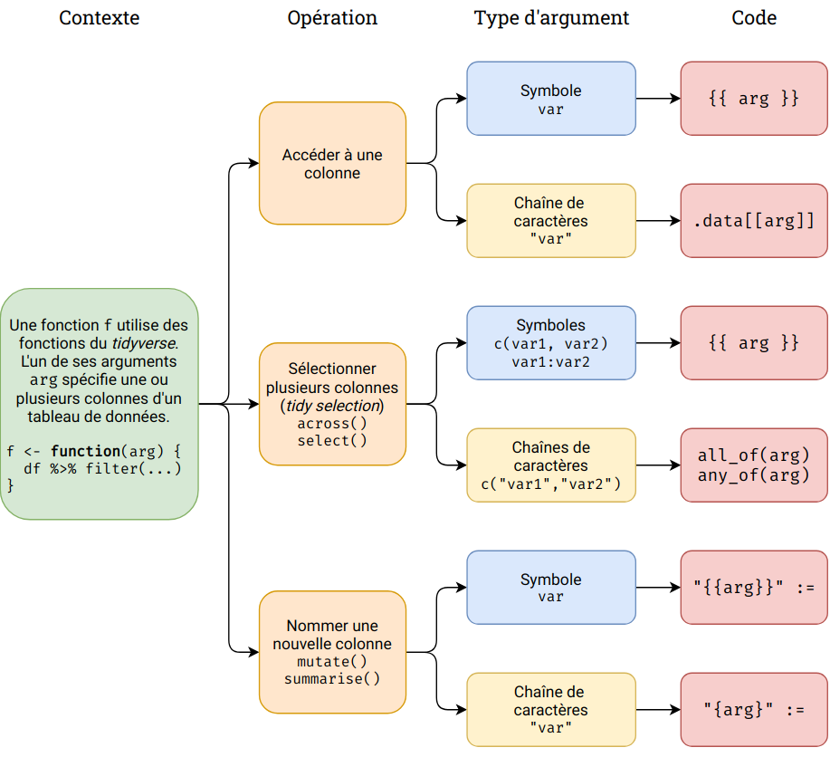

https://juba.github.io/tidyverse/19-programmer-tidyverse.html

### 10.8.7 Exemples de programmation avec le *tidyverse*

```r
# créer un df_part_reg par groupe de production ----
vege_creer_df_part_reg <- function(
    data,
    nom_indicateur,
    modalite_groupe_prod) {
  df <- data |>
    filter(str_starts(groupe_de_productions, {{ modalite_groupe_prod }})) |>
    select(
      echelle_geographique, territoire, type_de_production,
      groupe_de_productions, sous_groupe_de_productions,
      # paste0("rang_groupe_prod_", {{ nom_indicateur }}, "an_2023"),
      contains(nom_indicateur)) |>
    select(-matches("ss_groupe_prod")) |>
    rename_with(
        \(x) str_replace(
        x,
        paste0(
          {{ nom_indicateur }},
          "an_(\\d{4})_group_prod_part_reg"),
          "an_\\1"),
      .cols = starts_with({{ nom_indicateur }})) |>
    mutate(indicateur = {{ nom_indicateur }}, .after = "groupe_de_productions")

  # return facultatif. Certains considèrent que l'ajouter permet de rendre le code plus lisible.
  return(df)
}

# Créer des dataframes _part_reg par groupe de production pour "toutes" ----
vege_groupe_prod_surf_tot_bio_dep_pdl_part_reg <- vege_creer_df_part_reg(
  data = bio_vege_dep_pdl_part_reg_export,
  nom_indicateur = "surf_tot_bio_",
  modalite_groupe_prod = "toutes"
)
```

Impact des guillemets dans les appels de fonctions :  
- **Avec guillemets** : traité comme une chaîne de caractères littérale  
- **Sans guillemets** : traité comme une référence à une variable/colonne

Règle générale  
- Utiliser des guillemets quand on veut la valeur littérale  
- Ne pas utiliser de guillemets quand on fait référence à des noms de colonnes avec tidyeval

Ajouter une nouvelle ligne basée sur un ratio entre lignes : 1<sup>re</sup> méthode

```r
library(dplyr)
library(purrr)

# créer une fonction qui ajoute une ligne à un dataframe en calculant une nouvelle modalité d’une variable
# à partir de deux autres modalités de la même variable
# fonction pour ajouter ligne à partir caractéristiques autres lignes :
# calculer nouvelle modalité d'une variable à partir 2 autres modalités de la même variable
# ajouter ligne modalite_3
# en utilisant les valeurs associées aux lignes modalite_1 et modalite_2
# (valeur_3 pour var == modalite_3) = (valeur_1 pour var == modalite_1) / (valeur_2 pour var == modalite_2)
# L'opérateur := est nécessaire quand on utilise une référence de variable avec {{ }}
#pour un nom de colonne dynamique
# du côté gauche d'une affectation dans une fonction tidyverse
# où on crée/modifie des noms de colonnes

# 1- Transformer les données en format large
ajouter_ligne3_calcul_ligne1_sur_ligne2 <- function(tableau, var, valeur, modalite_1, modalite_2, modalite_3) {
  tableau_large <- tableau |>
  select(-c(geo, rica_region_soc2013_lib_dim2, rica_region_soc2013_mod_dim4, rica_region_soc2013_lib_dim4)) |>
  arrange(annref, {{ var }}) |>
  # var et valeur avec guillemets dans l'appel de fonction car utilisés comme chaînes de caractère dans pivot_wider
   pivot_wider(names_from = {{ var }},
              values_from = {{ valeur }})

# 2- Calcul du ratio
  tableau_large <- tableau_large |>
  mutate({{ modalite_3 }} := {{ modalite_1 }} / {{ modalite_2 }})

# 3- on conserve seulement année et nouvelle variable
  tableau_large_new_var <- tableau_large |>
    select(annref, {{ modalite_3 }})

# 4- on remet en format long
  # {{ var }} est interprété par exemple comme "rica_reg_dim4"
  tableau_new_line <- tableau_large_new_var |>
    pivot_longer(cols = {{ modalite_3 }},
                 names_to = {{ var }},
                 values_to = {{ valeur }})

# 5- on ajoute les nouvelles lignes au dataframe original
  tableau_new <- tableau |>
    bind_rows(tableau_new_line) |>
    arrange(annref, {{ var }}) |>
    relocate({{ valeur }}, .after = last_col())

# return facultatif. Certains considèrent que l'ajouter permet de rendre le code plus lisible.
return(tableau_new)
}

# Utiliser la fonction
# Dans ce code, tableau est le dataframe, var est la variable qu'on souhaite modifier,
# valeur est la colonne contenant les valeurs utilisées pour le calcul,
# et modalite_1, modalite_2, et modalite_3 sont les modalités de la variable var.
# var et valeur avec guillemets dans l'appel de fonction car utilisés comme chaînes de caractère dans pivot_wider()
rica_2018_2021_vol_pdl_2 <- ajouter_ligne3_calcul_ligne1_sur_ligne2(
                                  tableau = rica_2018_2021_vol_pdl_filtre_2,
                                  var = "rica_reg_dim4",
                                  valeur = "valeur_100",
                                  modalite_1 = n190_charges_approvisionnement,
                                  modalite_2 = n040_main_d_oeuvre_totale,
                                  modalite_3 = n054_charges_approvisionnement_par_UTA)

# calcul "n156_charges_tot_sans_charges_sociales_par_ha"
# à partir calcul n401_charges_totales_sans_charges_sociales / n020_surface_agricole_utile
rica_2018_2021_vol_pdl_2 <- ajouter_ligne3_calcul_ligne1_sur_ligne2(
                                  tableau = rica_2018_2021_vol_pdl_2,
                                  var = "rica_reg_dim4",
                                  valeur = "valeur_100",
                                  modalite_1 = n401_charges_totales_sans_charges_sociales,
                                  modalite_2 = n020_surface_agricole_utile,
                                  modalite_3 = n156_charges_tot_sans_charges_sociales_par_ha)
```

Ajouter une nouvelle ligne basée sur un ratio entre lignes : 2<sup>e</sup> méthode

```r
library(dplyr)
library(purrr)

# Autre possibilité qui nécessite d'utiliser annref comme 4 années concernées
# L'opérateur := est nécessaire quand on utilise une référence de variable avec {{ }}
# pour un nom de colonne dynamique
# du côté gauche d'une affectation dans une fonction tidyverse
# où on crée/modifie des noms de colonnes
ajouter_ligne <- function(df, var, valeur, modalite_1, modalite_2, modalite_3) {
  # Obtenir les années uniques
  annees <- unique(df$annref)

  # Créer une fonction qui traite une seule année
  calculer_ligne <- function(annee) {
    # Filtrer le dataframe pour l'année actuelle
    df_annee <- df |> filter(annref == annee)

  # Calculer la nouvelle valeur
  # modalite_1/2/3 avec guillemets dans l'appel de fonction car utilisés comme chaine de caractères dans filter()
  valeur_1 <- df_annee |>
    filter({{ var }} == modalite_1) |>
    pull({{ valeur }})

  valeur_2 <- df_annee |>
    filter({{ var }} == modalite_2) |>
    pull({{ valeur }})

  valeur_3 <- valeur_1 / valeur_2

  # Ajouter la nouvelle ligne
  # La fonction tibble() est utilisée pour créer un nouveau dataframe
  nouvelle_ligne <- tibble(annref = annee,
                          {{ var }} := modalite_3,
                          {{ valeur }} := valeur_3)

  # return facultatif. Certains considèrent que l'ajouter permet de rendre le code plus lisible.
  return(nouvelle_ligne)
  }

  # Utiliser map() avec list_rbind() pour appliquer la fonction à chaque année
  nouvelles_lignes <- annees |>
    map(\(x) calculer_ligne(x)) |>
    list_rbind()

  # Combiner avec le dataframe original
  df_new <- bind_rows(df, nouvelles_lignes)

  # return facultatif. Certains considèrent que l'ajouter permet de rendre le code plus lisible.
  return(df_new)  # On retourne le nouveau dataframe
}

# Utiliser la fonction
# modalite_1/2/3 avec guillemets dans l'appel de la fonction
# car utilisés comme chaine de caractères dans filter()
rica_2018_2021_vol_pdl_test <- ajouter_ligne(df = rica_2018_2021_vol_pdl_filtre_2,
                    var = rica_reg_dim4,
                    valeur = valeur_100,
                    modalite_1 = "n190_charges_approvisionnement",
                    modalite_2 = "n040_main_d_oeuvre_totale",
                    modalite_3 = "n054_charges_approvisionnement_par_UTA")

rica_2018_2021_vol_pdl_test2 <- rica_2018_2021_vol_pdl_test |>
  select(-c(rica_region_soc2013_lib_dim2, rica_region_soc2013_mod_dim4, rica_region_soc2013_lib_dim4)) |>
  filter(rica_reg_dim4 == "n054_charges_approvisionnement_par_UTA")
```

```r
# Définir une fonction pour le regroupement des facteurs
# {{ }} (double accolades) est utilisé pour évaluer l'expression au moment approprié.
# permet de capturer une expression non évaluée et de l'évaluer dans le contexte d'un dataframe.
# pour créer de nouvelles colonnes à partir d’un argument, on utilise les deux opérateurs {{ }} et :=
regrouper_especes <- function(data, colonne) {
  data <- data |>
    mutate("{{ colonne }}_regrpt1" := fct_collapse({{ colonne }},
                                    "1-poulets" = c("Poulets (y c. coquelets)", "Chapons, poulardes",
                                                  "Poules de réforme (filière œufs de consommation)",
                                                  "Coqs et poules de réforme (reproducteurs)"),
                                    "2-dindes" = c("Dindes"),
                                    "3-pintades" = c("Pintades (y c. chaponnées)"),
                                    "4-canards" = c("Canards à rôtir", "Canards gras"),
                                    "5-oies" = c("Oies à rôtir", "Oies grasses"),
                                    "6-petites_volailles" = c("Pigeons", "Cailles"),
                                    "7-lapins" = c("Lapins")
    )) |>
    mutate("{{ colonne }}_regrpt2" := fct_collapse({{ colonne }},
                                    "1-volailles" = c("Poulets (y c. coquelets)", "Chapons, poulardes",
                                                    "Poules de réforme (filière œufs de consommation)",
                                                    "Coqs et poules de réforme (reproducteurs)",
                                                    "Dindes", "Pintades (y c. chaponnées)",
                                                    "Canards à rôtir", "Canards gras", "Oies à rôtir",
                                                    "Oies grasses", "Pigeons", "Cailles"),
                                    "2-lapins" = c("Lapins")
    ))

  # return facultatif. Certains considèrent que l'ajouter permet de rendre le code plus lisible.
  return(data)
}

# Appliquer la fonction à chaque dataframe
vol_2024_2 <- regrouper_especes(vol_2024_2, espece)
vol_2023_2 <- regrouper_especes(vol_2023_2, espece)
```

```r
# fonction nb_beneficiaires pour les différentes années ----
calculer_nb_beneficiaires_par_departement <- function(annee) {
  an <- substr(as.character(annee), 3, 4)
  fichier_beneficiaires <- get(glue("fichier_beneficiaires_{annee}"))
  fichier_paiements_p1 <- get(glue("fichier_paiements_p1_{annee}"))
  fichier_paiements_ichn_aras <- get(paste0("fichier_paiements_ichn_aras_", annee))
  fichier_paiements_bio_maec <- get(paste0("fichier_paiements_bio_maec_", annee))

  # Construire la partie dynamique du chemin
  chemin_pac_annee <- get(glue("pac_{annee}"))

  # Construire le chemin complet
  chemin_fichier_benef <- glue("{chemin_aides_pac}{chemin_pac_annee}{fichier_beneficiaires}")
  chemin_fichier_paiements_p1 <- glue("{chemin_aides_pac}{chemin_pac_annee}{fichier_paiements_p1}")
  chemin_fichier_paiements_ichn_aras <- glue("{chemin_aides_pac}{chemin_pac_annee}{fichier_paiements_ichn_aras}")
  chemin_fichier_paiements_bio_maec <- glue("{chemin_aides_pac}{chemin_pac_annee}{fichier_paiements_bio_maec}")

  fic_benef <- readRDS(file = chemin_fichier_benef) |>
    as_tibble(.name_repair = make_clean_names) |>
    filter(nreg == "52")

  fic_paiements_p1 <- readRDS(file = chemin_fichier_paiements_p1) |>
    as_tibble(.name_repair = make_clean_names)

  fic_paiements_ichn_aras <- readRDS(file = chemin_fichier_paiements_ichn_aras) |>
    as_tibble(.name_repair = make_clean_names)

  fic_fichier_paiements_bio_maec <- readRDS(file = chemin_fichier_paiements_bio_maec) |>
    as_tibble(.name_repair = make_clean_names)

  nb_beneficiaires_pdl <- fic_benef |>
    left_join(fic_paiements_p1, join_by(pacage)) |>
    left_join(fic_paiements_ichn_aras, join_by(pacage)) |>
    left_join(fic_fichier_paiements_bio_maec, join_by(pacage)) |>
    mutate(
      benef_p1_ligne = as.numeric(.data[[paste0("aides_p1_", an)]] > 0),
      benef_p2_ligne = as.numeric((.data[[paste0("ichn_", an)]] > 0) |
                                    (.data[[paste0("aras_", an)]] > 0) |
                                    (.data[[paste0("bio_", an)]] > 0) |
                                    (.data[[paste0("maec_", an)]] > 0)),
      benef_p1_p2_ligne = as.numeric((benef_p1_ligne > 0) |
                                       (benef_p2_ligne > 0)),
      .after = pacage) |>
    group_by(dep) |>
    mutate(
      nb_beneficiaires_p1_dep = sum(benef_p1_ligne, na.rm = TRUE),
      nb_beneficiaires_p2_dep = sum(benef_p2_ligne, na.rm = TRUE),
      nb_beneficiaires_p1_p2_dep = sum(benef_p1_p2_ligne, na.rm = TRUE),
      .after = pacage) |>
    ungroup() |>
    mutate(
      nb_beneficiaires_p1_reg = sum(benef_p1_ligne, na.rm = TRUE),
      nb_beneficiaires_p2_reg = sum(benef_p2_ligne, na.rm = TRUE),
      nb_beneficiaires_p1_p2_reg = sum(benef_p1_p2_ligne, na.rm = TRUE),
      .after = nb_beneficiaires_p1_p2_dep) |>
    distinct(
      dep, nb_beneficiaires_p1_dep,
      nb_beneficiaires_p2_dep,
      nb_beneficiaires_p1_p2_dep,
      nb_beneficiaires_p1_reg,
      nb_beneficiaires_p2_reg,
      nb_beneficiaires_p1_p2_reg) |>
    arrange(dep)

  # return facultatif. Certains considèrent que l'ajouter permet de rendre le code plus lisible.
  return(nb_beneficiaires_pdl)
}

# uitilisation de la fonction pour les différentes années
nb_beneficiaires_2020 <- calculer_nb_beneficiaires_par_departement(annee = 2020)
nb_beneficiaires_2021 <- calculer_nb_beneficiaires_par_departement(annee = 2021)
nb_beneficiaires_2022 <- calculer_nb_beneficiaires_par_departement(annee = 2022)
nb_beneficiaires_2023 <- calculer_nb_beneficiaires_par_departement(annee = 2023)

# Combiner les resultats des différentes années
# Renommer les colonnes de chaque dataframe pour éviter les conflits
nb_beneficiaires_2020_suffixe <- nb_beneficiaires_2020 |>
rename_with(
  \(x) paste0(x, "_2020"),
  -dep
)

nb_beneficiaires_2021_suffixe <- nb_beneficiaires_2021 |>
rename_with(
  \(x) paste0(x, "_2021"),
  -dep
)

nb_beneficiaires_2022_suffixe <- nb_beneficiaires_2022 |>
rename_with(
  \(x) paste0(x, "_2022"),
  -dep
)

nb_beneficiaires_2023_suffixe <- nb_beneficiaires_2023 |>
rename_with(
  \(x) paste0(x, "_2023"),
  -dep
)

# Effectuer les jointures
nb_beneficiaires_pac_2020_2023 <- nb_beneficiaires_2020_suffixe |>
  left_join(nb_beneficiaires_2021_suffixe, join_by(dep)) |>
  left_join(nb_beneficiaires_2022_suffixe, join_by(dep)) |>
  left_join(nb_beneficiaires_2023_suffixe, join_by(dep))
```

## 10.9 Paramétrer une chaîne de caractères avec le package `glue`

Construire une chaîne de caractères agrégeant des parties fixes et des parties variables peut devenir fastidieux avec la fonction `paste0`(beaucoup de quotes et de virgules).  
Le package `glue` peut être intéressant : on met entre accolades `{}` les parties de la chaîne de caractères qui doivent être évaluées lors de la construction de la chaîne finale.

```r
library(glue)

# Exemple simple
name <- "Alice"
age <- 30

# Avec glue
glue("Je m'appelle {name} et j'ai {age} ans")

# Equivalent avec paste0
paste0("Je m'appelle ", name, " et j'ai ", age, " ans")

# Exemple plus complexe
data <- data.frame(
  prenom = c("Alice", "Bob"),
  age = c(30, 25),
  ville = c("Paris", "Lyon"))

# Avec glue
glue_data(data,
  "{prenom} a {age} ans et habite à {ville}")

# Multiples lignes
glue("
  Nom: {name}
  Age: {age}
  Ville: {data$ville[1]}
")
```

## 10.10 Style de codage

Suivre le [style de code du tidyverse](https://style.tidyverse.org/).

Quelques principes à retenir :

- éviter le mélange de majuscules et minuscules dans les noms des objets et donc utiliser la [snake case](https://fr.wikipedia.org/wiki/Snake_case) (minuscules et underscores) pour les noms de variables et de fonctions (ma_variable, ouvrir_ra()) ;
- nommer clairement ses variables et fonctions (pas de a <- “84” mais insee_reg <- “84”) ;
- retourner à la ligne après le pipe |> (privilégier le pipe natif) ;
- conserver des lignes pas trop longues (80 caractères si possible, pas plus de 100) ;
- aérer le code (espace après les , avant et après les opérateurs =, ==, <-, etc.) ;
- utiliser TRUE et FALSE plutôt que T et F ;
- utiliser, comme délimiteurs de chaînes, les guillemets anglais ” plutôt que les apostrophes ’ ;
- indiquer les noms des arguments dans les fonctions utilisées, au moins pour les arguments secondaires : read_delim(“fic.txt”, delim = “;”, dec = “,”, skip = 2) plutôt que read_delim(“fic.txt”, “;”, “,”, 2).

Le nommage des objets : variables, constantes, fonctions doit être explicite. Une fonction est par exemple nommée à partir d’un verbe d’action à l’infinitif : ouvrir_fichier_enquete()

# 11 Foire aux questions

## 11.1 Où trouver de la documentation ?

utilitR : documentation collaborative sur le langage de programmation R réalisée par des agents de l’Insee  
https://book.utilitr.org/

Documentation réalisée par un groupe de référents en R du ministère de la transition écologique  
https://mtes-mct.github.io/parcours-r/

Site de formation R du Ministère de l’agriculture et de la souveraineté alimentaire  
https://ssm-agriculture.github.io/site-formations-R/

Site [Introduction à R et au tidyverse](https://juba.github.io/tidyverse)

Ces 4 sites servent de source pour alimenter le présent [document](https://christophefouchard.github.io/pratique_R/pratique_R.html).

Il est également disponible sur Cerise  
- se rendre dans  
~/CERISE/01-Espace-de-Partage/SRISE/Pays-De-La-Loire/Partage_R  
- faire un clic gauche sur “pratique_R.html” et choisir “Voir dans le navigateur Web”

Les lettres du groupe des utilisateurs de R (GUR) sont aussi très utiles :

`Comment fai’R pour ajouter des 0 manquants en début de chaîne ?`

`Comment fai’R pour choisir la bonne fonction de jointure ?`

`Comment fai’R pour détecter les valeurs manquantes dans une table ?`

`Comment fai’R un tri personnalisé dans une table ?`

`Comment fai’R pour importer des données depuis un fichier Excel contenant des en-têtes ?`

`Comment fai’R : les paramètres de mutate()`

`Comment fai’R : créer un tableau de contingence`

`Comment fai’R : le top 10 des fonctions R qui changent la vie`

`Comment fai’R : mettre en forme un pourcentage`

`Comment fai’R : choisir les niveaux de croisement d’une agrégation`

`Comment fai’R : R et tableurs`

`Comment fai’R : un diagramme des principales étapes d’un programme`

Elles sont disponibles sur : *~/CERISE/01-Espace-de-Partage/SSP/BMIS/comment_fair*.

On peut aussi s’appuyer sur des [aide-mémoire](https://posit.co/resources/cheatsheets) (antisèches ou “feuilles de triche”).

## 11.2 Comment nommer les fichiers ?

Les différents segments du nom d’un fichier sont séparés par un underscore (le caractère “_“).

Les accents et les caractères spéciaux ne doivent pas être utilisés.

Idéalement, le nom du fichier ne sera pas trop long et suffisamment descriptif.

## 11.3 Aide sur une fonction

Pour obtenir de l’aide sur une fonction (installée, peut-être non chargée) :

```r
??nom_fonction
```

Pour obtenir de l’aide sur une fonction (installée et chargée) :

```r
?nom_fonction
help(nom_fonction)
```

Documentation simplifiée : vignettes

Les vignettes sont des documents qui aident à prendre en main un package en identifiant ses fonctions les plus importantes, et en montrant un ou plusieurs cas d’usage.

Pour lister les vignettes relatives à un package (par exemple dplyr):

```r
vignette(package = "dplyr")
```

Pour visualiser une vignette donnée :

```r
vignette("rowwise", package = "dplyr") # dans RStudio
RShowDoc("rowwise", package = "dplyr") # dans le navigateur web
```

## 11.4 L’encodage

Utiliser l’encodage `UTF-8`. Le nombre minimal de bits est 8. En fait, il représente les premiers caractères (ceux de l’ASCII) sur un octet, les suivants sur 2 octets, 3 et jusqu’à 4 octets.

https://orion.agriculture/confluence/pages/viewpage.action?pageId=285442455

## 11.5 Les types de valeurs dans R

Une valeur constitue l’unité de base des données pour R. Comme pour la plupart des logiciels, elles peuvent être de trois **types** :

- **Numérique** : entier, double
- **Caractère** : texte ou code
- **Logique** : booléens

*En anglais : numeric, character et logical*

Les vecteurs peuvent être de classes différentes, selon le type de données qu’ils contiennent.

On a ainsi des vecteurs de type `integer` ou `double`, qui contiennent respectivement des nombres entiers ou décimaux ; des vecteurs de type `character`, qui contiennent des chaînes de caractères ; et des vecteurs de type `logical`, qui ne peuvent contenir que les valeurs vraie (`TRUE`) ou fausse (`FALSE`).

Chaque variable est du type de son contenu (numeric, character, logical).

À chaque type de variable correspond une utilisation. Lors de l’import des données, un type est affecté automatiquement par R. Mais le type peut être erroné. Il suffit alors de les convertir :

```r
base <- mutate(base0, LIBGEO = as.character(LIBGEO))
```

On peut convertir un vecteur d’un type à un autre avec les fonctions de forme as.XXX :  
`as.character()`, `as.numeric()`, `as.factor()` et `as.logical()`.

Si une valeur ne peut pas être convertie, elle est remplacée par un `NA`, et R affiche un avertissement.

```r
as.character(1:3)
as.logical(c(0, 2, 4))
as.numeric(c("foo", "23"))
```

```
## Warning: NAs introduits lors de la conversion automatique
```

On peut aussi gérer les types au moment de l’importation (par exemple avec le paramètre `colClasses`).

### 11.5.1 `Factor` pour une variable catégorielle

Si les valeurs prises par la variables correspondent à un nombre fini de modalités, **la variable peut être du type `factor`**. Ses composantes sont toujours d’un des 3 types décrits ci-dessus mais il est possible d’employer des fonctions spécifiques au traitement de modalités.

Un `factor` est une manière de représenter une variable catégorielle, généralement utilisée lorsqu’il y a un nombre restreint de catégories (par exemple les tranches d’âges).

Les différentes modalités autorisées de la variable, appelées `levels`, sont associées chacune à un entier. Le `factor` stocke alors les valeurs des entiers à la place des modalités complètes. Cela permet :

- Un stockage efficace en évitant de stocker de multiples fois de longs labels.
- De formaliser le caractère catégoriel de la variable en limitant les valeurs acceptées.
- De faciliter certaines analyses en identifiant ces variables comme catégorielles et non autre chose (texte, numérique etc.).

Les `factors` peuvent être délicats à manipuler et sont souvent source d’erreur car les valeurs intrinsèques de l’objet sont les entiers codant les `levels`.

### 11.5.2 Travail sur les dates

```r
itavi <- itavi |>
  mutate(an_mois_date = convertToDate(an_mois))

# itavi <- itavi |>
# mutate(an_mois = substr(as.character(an_mois_date), 1, 7))

# itavi <- itavi |>
# gsub("-", "_", itavi$an_mois)

# itavi <- itavi |>
# str_replace_all("-","_")

itavi <- itavi |>
  mutate(annee = year(an_mois_date),
         mois = month(an_mois_date),
         an_mois = paste0(annee, "_", mois))
```

## 11.6 Les vecteurs

Un *vecteur* est un ensemble d’une seule dimension de 1 ou plusieurs éléments du même type. Ces vecteurs peuvent être vus comme des colonnes de valeurs toutes du même type (numérique, chaîne de caractères, booléen, catégorie).

**Vecteurs** : suite unidimensionnelle de **valeurs** ayant le même type.

Différentes fonctions permettent de créer des vecteurs.

```r
vect_num <- c(1, 160, 2, 9)
vect_txt <- c("Je", "programme", "en", "R")
sequence <- seq(from = 1, to = 10, by = 1)
sequence_pareille <- 1:10
repetition <- rep("bla", 3)
```

La fonction `seq()` (comme séquence) génère une séquence de valeurs numériques. Elle prend comme paramètre un point de départ (1^er paramètre from =), un point d’arrivée (2e paramètre to =) et le pas (3<sup>e</sup> paramètre by =) qui indique l’écart régulier souhaité entre deux valeurs successives.

L’opérateur `:` permet de générer un vecteur comprenant l’ensemble des entiers entre deux nombres entiers :

```r
x <- 1:10
x
```

La commande `c()` est à placer devant une liste. Cette fonction, appelée `collecteur`, permet de combiner plusieurs valeurs pour les ranger dans un objet. `c` est l’abréviation de *combine*.

L’avantage d’un vecteur est que lorsqu’on lui applique une opération, celle-ci s’applique à toutes les valeurs qu’il contient.

On peut accéder à un élément particulier d’un vecteur en faisant suivre le nom du vecteur de crochets contenant le numéro de l’élément désiré.

```r
diplome[2]
```

Cette opération, qui utilise l’opérateur `[]`, permet donc la sélection d’éléments d’un vecteur.

Si on affiche dans la console un vecteur avec beaucoup d’éléments, ceux-ci seront répartis sur plusieurs lignes. Par exemple, si on a un vecteur de 50 nombres on peut obtenir quelque chose comme :

```
 [1] 294 425 339 914 114 896 716 648 915 587 181 926 489
[14] 848 583 182 662 888 417 133 146 322 400 698 506 944
[27] 237 324 333 443 487 658 793 288 897 588 697 439 697
[40] 914 694 126 969 744 927 337 439 226 704 635
```

On remarque que R ajoute systématiquement un nombre entre crochets au début de chaque ligne : il s’agit en fait de la position du premier élément de la ligne dans le vecteur. Ainsi, le 848 de la deuxième ligne est le 14e élément du vecteur.

Pour connaitre le type d’un vecteur, on peut utiliser la fonction `class()`.

Des fonctions `is.xxxx()` permettent de tester les valeurs. Le résultat renvoyé est un booléen.

```
`is.numeric(x)` : est-ce que x contient des valeurs de type numérique ?

`is.character(x)` : est-ce que x contient des valeurs de type chaîne de caractères ?

`is.logical(x)` : est-ce que x contient des valeurs de type booléen ?
```

**Facteurs** : vecteur qui prend un nombre limité de modalités (exemple : sexe). Il est défini par les modalités possibles, appelées niveaux (`levels`) et les libellés associés (`labels`). On parle aussi de variables qualitatives ou catégorielles (de type catégoriel).

Les variables sont principalement de 2 types : variable *quantitative* (variable numérique pouvant prendre un grand nombre de valeurs : l’âge, le revenu, un pourcentage…) et variable *qualitative* (variable pouvant prendre un nombre limité de valeurs appelées modalités : le sexe, la profession, le dernier diplôme obtenu…).

### 11.6.1 Extraire un vecteur : $ et `pull()`

Pour accéder aux variables (colonnes) d’un tableau, on peut utiliser l’opérateur `$`. L’opérateur $ est utilisé pour accéder directement à une colonne par son nom.

La fonction `table$colonne` renvoie la colonne nommée `colonne` du tableau `table`, c’est-à-dire un vecteur, en général de nombres ou de chaînes de caractères.

Si on souhaite afficher seulement les premières ou dernières valeurs d’une variable, on peut utiliser les fonctions `head` et `tail`.

```r
head(df$age)
```

```r
tail(df$age, 10)
```

Le deuxième argument numérique permet d’indiquer le nombre de valeurs à afficher.

L’équivalent de l’opérateur $ pour accéder aux éléments d’une liste ou d’un dataframe est la fonction [[ ]].

```r
# Accès à la colonne 'colonne_1'
colonne_data <- df[["colonne_1"]]
```

La fonction `pull()` de dplyr permet d’extraire sous forme de vecteur une variable d’un *dataframe.*

```r
# Utilisation de pull() pour extraire la colonne 'a'
vecteur_a <- df |>
  pull(a)

# Utilisation de $
vecteur_a <- df$a

# Autre façon d'extraire la colonne 'a' en tant que vecteur avec [[ ]]
vecteur_a <- df[["a"]]

stations_de_la_table_prelevement <- pull(prelevement, code_station)
stations_de_la_table_prelevement <- unique(stations_de_la_table_prelevement)
```

La fonction `identical` est utilisée pour comparer des objets, pour vérifier si le contenu de deux variables est identique.  
- **Objectif :** - Vérifie si deux objets R sont strictement identiques.

- **Utilisation :**
  - `identical(x, y)` retourne `TRUE` si `x` et `y` sont exactement les mêmes objets, sinon `FALSE`.

```r
# Pour vérifier si le contenu de deux variables est identique
identical(rica_2018_2021_qualite_oui$valeur,
          rica_2018_2021_qualite_oui$valeur_extrapolee)
```

## 11.7 Les dataframes

Plusieurs vecteurs de types différents possédant un même nombre de lignes peuvent être accolés pour former une **dataframe**. Les dataframes sont les objets les plus courants dans le traitement de données usuel. Il s’agit de tableaux dont les lignes correspondent à des observations et les colonnes à des variables.

Ces dataframes peuvent être créées par association des vecteurs avec les fonctions :

```r
dataframe_a <- data.frame(vect_num, vect_txt)
dataframe_b <- bind_cols("vect_num" = vect_num, "vect_txt" = vect_txt)
```

Une dataframe peut aussi être créée par l’import d’un tableau.

Il est possible d’accéder aux éléments d’une dataframe à partir du numéro de ligne et de colonne, grâce aux crochets :

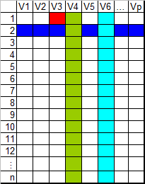

- `base[1,3]` $\rightarrow$ valeur de la première ligne et de la troisième colonne
- `base[2,]` $\rightarrow$ toutes les variables pour la 2e observation
- `base[,4]` $\rightarrow$ toutes les observations de la quatrième colonne
- `base[,’V6’]` $\rightarrow$ toutes les observations de la variable V6

Le *dataframe* est constitué de - n lignes (observations) - p colonnes (variables)

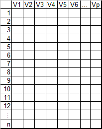

Les colonnes étant des vecteurs, il faut que toutes les valeurs soient du même type. Ce n’est pas le cas pour les lignes qui représentent les individus statistiques.

Un *data frame* (ou tableau de données, ou table) est un type d’objet R qui contient des données au format tabulaire, avec les observations en ligne (individus) et les variables (caractéristiques) en colonnes, comme dans une feuille de tableur de type Calc ou Excel.

Une manière d’afficher le contenu du tableau est de cliquer sur l’icône en forme de tableau à droite du nom de l’objet dans l’onglet *Environment* :

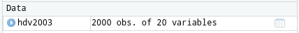

View icon

Ou d’utiliser la fonction `View` :

```r
View(hdv2003)
```

Dans les deux cas le tableau devrait s’afficher dans RStudio avec une interface de type tableur.

On peut lister et modifier les noms des colonnes d’un tableau avec les fonctions `names()` ou `colnames()` (qui sont équivalentes). Ces fonctions ont deux utilités :  
- nommer les colonnes d’un data-frame  
- connaître les noms des colonnes d’un data-frame.

Pour obtenir le nombre de lignes et de colonnes dans un *data frame* on utilise les fonctions `nrow()` et `ncol()`.  
La fonction `dim(x)` renvoie le vecteur c(nrow(x),ncol(x)).

## 11.8 Le `tibble` : un `data.frame` amélioré

**Le `tibble` est une version améliorée du `data.frame` de base.** Il s’agit d’un `data.frame` standard, avec quelques propriétés supplémentaires qui rendent son utilisation plus facile.

**Pour convertir un `data.frame` en `tibble` on utilise la fonction `tibble::as_tibble()`.** Dans l’exemple suivant, on charge la table de la base permanente des équipements puis on la convertit en `tibble`.

```r
# Charger la base permanente des équipements
bpe_ens_2018 <- doremifasolData::bpe_ens_2018
# Convertir ce data.frame en tibble
bpe_ens_2018_tbl <- as_tibble(bpe_ens_2018)
```

- **L’affichage des `tibbles` est meilleur que celui des `data.frames`.** Même sans la fonction `head()`, l’affichage d’un `tibble` affiche les dimensions de celui-ci (nombres de lignes et de colonnes), ainsi que le type des variables (en-dessous des noms des colonnes).

L’affichage print dans la console est amélioré ; il affiche notamment les types des colonnes et limite le nombre de lignes.

Les tableaux de données au format *tibble* autorisent des noms de colonnes invalides pour les *data frames* (espaces, caractères spéciaux, nombres…). Quand on veut utiliser des noms de ce type, on doit les entourer avec des *backticks* (`) (“apostrophes inverses”).

https://book.utilitr.org/03_Fiches_thematiques/Fiche_tidyverse.html#le-tibble-un-data.frame-am%C3%A9lior%C3%A9

### 11.8.1 Sélection de lignes et de colonnes

Il existe plusieurs manières de sélectionner des éléments dans un tableau de données.

Ainsi, on peut sélectionner une colonne via l’opérateur `$`.

```r
df$fruit
```

Comme un tableau de données est en réalité une liste de colonnes, on peut aussi utiliser l’opérateur `[[]]` pour sélectionner l’une de ses colonnes, par position ou par nom.

```r
df[["fruit"]]
df[[2]]
```

On peut également utiliser l’opérateur `[,]` pour sélectionner à la fois des lignes et des colonnes, en lui passant deux arguments séparés par une virgule : d’abord la sélection des lignes puis celle des colonnes. Dans les deux cas on peut sélectionner par position, nom ou condition. Si on laisse un argument vide, on sélectionne l’intégralité des lignes ou des colonnes.

```r
# Lignes 1 et 3 et colonne "poids"
df[c(1, 3), "poids"]
```

```r
# Toutes les lignes et colonnes "poids" et "fruit"
df[, c("poids", "fruit")]
```

```r
# Lignes pour lesquelles poids > 150, et toutes les colonnes
df[df$poids > 150, ]
```

```r
library(stringr)
# Colonnes dont le nom contient un "o", et toutes les lignes
df[, str_detect(names(df), "o")]
```

Attention, le comportement de `[,]` est différent entre les *tibbles* et les *data frame* lorsqu’on ne sélectionne qu’une seule colonne. Dans le cas d’un *data frame*, le résultat est un vecteur, dans le cas d’un *tibble* le résultat est un tableau à une colonne.

```r
df[, "fruit"]
```

```r
df_tib[, "fruit"]
```

Cette différence peut parfois être source d’erreurs, notamment quand on développe une fonction qui prend un tableau de données en argument.

### 11.8.2 Modification

On peut utiliser `[[]]` et `[,]` avec l’opérateur d’assignation `<-` pour modifier tout ou partie d’un tableau de données.

```r
# Création d'une nouvelle colonne poids_kg
df[["poids_kg"]] <- df$poids / 1000
df
```

```r
# Remplacement de la valeur de la colonne "fruit" pour les lignes
# pour lesquelles "fruit" vaut "Citron"
df[df$fruit == "Citron", "fruit"] <- "Agrume"
df
```

L’utilisation des opérateurs `[[]]` et `[,]` sur un tableau de données peut sembler redondante et moins pratique que l’utilisation des verbes de `dplyr` comme `select()` ou `filter()`. Ils peuvent cependant être utiles lorsqu’on souhaite éviter les complications liées à l’utilisation du *tidyverse* à l’intérieur de fonctions.

## 11.9 Les fonctions et les valeurs particulières (NA, NaN, Inf)

- `NA` : valeur manquante (*Not Available*, non disponible) dans un dataframe ou en résultat d’une fonction. Cette valeur particulière est utilisée pour indiquer une valeur manquante, qu’il s’agisse d’un nombre, d’une chaîne de caractères, etc.

`NA` est de type logical ; il existe des variantes pour les autres types : `NA_integer_`, `NA_real_`, `NA_character_`.

Il faut utiliser `is.na` pour vérifier si une valeur vaut `NA` :

```r
is.na(NA)
[1] TRUE
```

- `NaN` : pas un nombre (*Not a Number*) lorsqu’une fonction tente de diviser par 0
- `NULL` désigne l’absence de valeur. À la différence de NA qui désigne une valeur inconnue / manquante, NULL indique qu’il n’y a pas de valeur.  
  NULL peut être utilisé pour assigner des valeurs par défaut à des arguments d’une fonction ou pour supprimer des éléments.
- `-Inf`, `Inf` : inﬁni positif ou négatif lorsque une fonction diverge

Une valeur manquante peut perturber l’exécution d’une fonction :

```r
V1 <- c(1, 14, NA, 32.7)

mean(V1)              # renvoie NA
mean(V1, na.rm = TRUE)   # renvoie 15.9
```

R considère par défaut qu’il ne peut pas calculer la moyenne si une des valeurs n’est pas disponible. Dans ce cas il considère que la moyenne est elle-même “non disponible” et renvoie donc `NA` comme résultat.

On peut cependant indiquer à `mean` d’effectuer le calcul en ignorant les valeurs manquantes. Ceci se fait en ajoutant un argument supplémentaire, nommé `na.rm` (abréviation de *NA remove*, “enlever les NA”), et de lui attribuer la valeur `TRUE` (*vrai*).

```r
mean(tailles, na.rm = TRUE)
```

Positionner le paramètre `na.rm` à `TRUE` indique à la fonction `mean` de ne pas tenir compte des valeurs manquantes dans le calcul.

Si on ne dit rien à la fonction `mean`, cet argument a une valeur par défaut, en l’occurrence `FALSE` (faux), qui fait qu’il ne supprime pas les valeurs manquantes.

La fonction `coalesce(x, y)` permet de remplacer les valeurs manquantes de x par la valeur de y.

## 11.10 Travailler avec les valeurs manquantes `NA`

```r
library(janitor) # pour round_half_up

# Calculer le nombre de valeurs manquantes dans chaque ligne
# Calculer proportion de NA par ligne / ncol (nombre de colonnes)
lignes_avec_na <- df |>
  mutate(
    nb_na = rowSums(is.na(.)),
    pct_na = (nb_na / ncol(.)) * 100
  )

lignes_avec_bcp_na <- (nombre_na / ncol(df)) >= 50/100

# mettre NA pour variable d'évolution avec regroupement
otex_regroupe <- otex_regroupe |>
  mutate(evol_2020_2019 = case_when(
        otex_code_regr %in% c("otex_5374_5100", "otex_4813_4840") ~ as.numeric(NA),
        .default = evol_2020_2019),
    evol_2020_2010_par_an = case_when(
         otex_code_regr %in% c("otex_5374_5100", "otex_4813_4840") ~ as.numeric(NA),
         .default = evol_2020_2010_par_an)
  )

# calcul evolution
otex_regroupe <- otex_regroupe |>
  mutate(tx_evol_2020_2010_par_an = round_half_up((((an_2020 / an_2010)**(1/10)-1) * 100), 3),
         tx_evol_2020_2019 = round_half_up(((an_2020 / an_2019 -1) * 100), 3),
         otex_code = substr(otex_code_regr, 6, 10)) |>
  arrange(otex_code_regr) |>
  left_join(otex |>
              select(otex_code, otex_lib),
            join_by(otex_code)) |>

# remplacement valeurs NA pour regroupements
otex_regroupe <- otex_regroupe |>
  mutate(evol_2020_2010_par_an = case_when(
    is.na(evol_2020_2010_par_an) ~ round_half_up(tx_evol_2020_2010_par_an, 1),
    .default = evol_2020_2010_par_an),
    evol_2020_2019 = case_when(
      is.na(evol_2020_2019) ~ round_half_up(tx_evol_2020_2019, 1),
      .default = evol_2020_2019))

# remplacement valeurs NA
unique(vab_agri_2020_2$libreg)
vab_agri_2020_3 <- vab_agri_2020_2 |>
  filter(libreg != "France métropolitaine hors Ile-de-France") |>
  mutate(reg = case_when(
      is.na(reg) ~ "FM",
    .default = reg))

# transformation des valeurs numériques manquantes par des zéros
exploit_prod_anim_pdl <- exploit_prod_anim_pdl |>
  mutate(
    across(
      where(is.numeric),
      \(x) replace(x, is.na(x), 0)
    )
  )
```

### 11.10.1 `replace_na` : remplacer des valeurs manquantes

La fonction `replace_na` permet de remplacer des valeurs manquantes (`NA`). Cette fonction peut être utilisée de deux façons, que l’on va illustrer avec les données suivantes :

```r
df <- tibble::tibble(x = c(1, 2, 3, NA), y = c("a", NA, "b", NA))

df
```

Premier usage : on remplace les valeurs manquantes **dans une colonne** d’un `data.frame`. Dans ce cas, la fonction prend deux arguments : le nom de la variable et la valeur utilisée pour remplacer les valeurs manquantes. Voici un exemple :

```r
library(tidyr) # pour replace_na

df |>
  dplyr::mutate(x = replace_na(x, 999))
```

```r
# remplacera tous les NA de la colonne x par la valeur 'val'
# Attention: 'val' doit être du même type que les valeurs de x
data |>
  mutate(x = replace_na(x, val))
```

Second usage : on remplace les valeurs manquantes **dans toutes les colonnes** d’un `data.frame`. Dans ce cas, la fonction prend deux arguments : le nom du `data.frame`, et une liste donnant pour chaque variable la valeur à utiliser pour remplacer les valeurs manquantes. Voici un exemple :

```r
df |>
  replace_na(list(x = 999, y = "zzz"))

# Remplacement des valeurs manquantes dans les colonnes A et B
data_sans_NA_1 <- replace_na(data, list(A = 0, B = "manquant"))

data_sans_NA_2 <- data |>
  mutate(A = replace_na(A, 0),
         B = replace_na(B, "manquant")
         )
```

```r
# Créer une nomenclature agrégée libelle_ab_regroupt à partir de libelleonab et libelle_ab_2
# La valeur de libelle_ab_regroupt est basée sur libelle_ab_2
# si libelle_ab_2 correspond à "Pommes" et sur libelleonab sinon

# pb avec == si présence de valeurs manquantes
bio_pdl_nomenclature_pb_na <- bio_pdl_nomenclature |>
  mutate(libelle_ab_regroupt = if_else(libelle_ab_2 == "Pommes", true = libelle_ab_2, false = libelleonab))

unique(bio_pdl_nomenclature_pb_na$libelle_ab_regroupt)

# %in% permet de gérer la présence de valeurs manquantes
bio_pdl_nomenclature <- bio_pdl_nomenclature |>
  mutate(libelle_ab_regroupt = if_else(libelle_ab_2 %in% c("Pommes"),
                                      true = libelle_ab_2,
                                      false = libelleonab))

unique(bio_pdl_nomenclature$libelle_ab_regroupt)

# on remplace au préalable les valeurs manquantes si on souhaite utiliser ==
bio_pdl_nomenclature_renommage_na <- bio_pdl_nomenclature |>
  mutate(libelle_ab_2 = replace_na(libelle_ab_2, "hors_pommes"))

# Créer une nomenclature agrégée libelle_ab_regroupt à partir de libelleonab et libelle_ab_2
# La valeur de libelle_ab_regroupt est basée sur libelle_ab_2
# si libelle_ab_2 == "Pommes" et sur libelleonab sinon
bio_pdl_nomenclature_gestion_na <- bio_pdl_nomenclature_renommage_na |>
  mutate(libelle_ab_regroupt = if_else(libelle_ab_2 == "Pommes",
                                      true = libelle_ab_2,
                                      false = libelleonab))

unique(bio_pdl_nomenclature$libelle_ab_regroupt)
```

## 11.11 Les listes

Les listes regroupent plusieurs éléments ensemble. Une liste peut donc contenir des vecteurs, des listes, des tableaux de données. Une liste dans R est une structure de données qui peut contenir des éléments de types différents (contrairement aux vecteurs qui doivent être homogènes). Contrairement à un vecteur, qui doit contenir des éléments du même type (par exemple, tous numériques ou tous caractères), une liste peut mélanger différents types.

### 11.11.1 Création

On construit une liste avec la fonction `list`.

On peut nommer les éléments à la création de la liste.

```r
liste <- list(nombre = 1, char = "foo", vecteur = c("Pomme", "Citron"))
liste
```

On peut utiliser `names()` pour afficher ou modifier les noms des éléments.

```r
names(liste)
```

Quand la liste est plus complexe, la fonction `str` peut être utile pour afficher de manière plus compacte la structure de la liste.

```r
str(liste)
```

### 11.11.2 Sélection d’éléments

Il y a deux opérateurs différents qui permettent de sélectionner les éléments d’une liste : les crochets simples `[]` et les crochets doubles `[[]]`. La différence entre ces deux opérateurs est souvent source de confusion.

Partons de la liste suivante :

```r
liste <- list(1:5, "foo", c("Pomme", "Citron"))
liste
```

Si on utilise les crochets simples pour sélectionner le premier élément de cette liste, on notera que le résultat est une liste à un seul élément.

```r
liste[1]
```

Si on utilise les crochets doubles, pn obtient cette fois-ci non pas une liste composée du premier élément, mais le contenu de ce premier élément.

```r
liste[[1]]
```

La différence est importante, mais pas toujours facile à retenir. On peut utiliser deux petites astuces mnémotechniques :

- si une liste est un train composé de plusieurs wagons, `[1]` retourne le premier wagon du train, tandis que `[[1]]` renvoie le contenu du premier wagon.
- une alternative est de considérer que `[[]]` va chercher “plus profondément” que `[]`.

Un autre point important est que si on passe plusieurs éléments à `[[]]`, la sélection se fait d’une manière récursive peu intuitive et source d’erreurs. Il est donc conseillé de **toujours utiliser** `[[]]` **avec un seul argument**, et d’utiliser `[]` si on souhaite sélectionner plusieurs éléments d’une liste.

```r
liste[c(1, 2)]
```

En résumé :

- si on souhaite récupérer uniquement le contenu d’un élément d’une liste, on utilise `[[]]` avec un seul argument.
- si on souhaite récupérer une nouvelle liste en sélectionnant des éléments de laliste actuelle, on utilise `[]` avec un ou plusieurs arguments.

Comme pour les vecteurs, on peut utiliser des nombres négatifs avec `[]` pour exclure des éléments plutôt que les sélectionner, et on peut également utiliser les fonctions `head()` et `tail()`.

Si la liste est nommée, on peut sélectionner des éléments par noms avec les deux opérateurs.

```r
liste <- list(nombre = 1, char = "foo", vecteur = c("Pomme", "Citron"))
liste[c("nombre", "char")]
liste[["vecteur"]]
```

On peut aussi utiliser l’opérateur `$`, qui équivaut à `[[]]` :

```r
liste$vecteur
```

### 11.11.3 Utilisation

En tant que généralisation des vecteurs atomiques, les listes sont utiles dès qu’on souhaite regrouper des éléments complexes ou hétérogènes.

On les utilisera par exemple pour retourner plusieurs résultats depuis une fonction.

```r
indicateurs <- function(x) {
    list(
        moyenne = mean(x),
        variance = var(x)
    )
}

x <- 1:10
res <- indicateurs(x)
res$moyenne
res$variance
```

On utilise également les listes pour stocker des objets complexes (par exemple des tableaux ) et leur appliquer des fonctions.

Piège courant à éviter : la confusion entre `[ ]` et `[[ ]]`.

```r
# Piège : Confusion entre [] et [[]]
ma_liste[1]      # renvoie une liste
ma_liste[[1]]    # renvoie l'élément
```

## 11.12 Qu’est-ce que l’opérateur `pipe` ?

Lorsqu’on enchaîne les manipulations sur une table de données, un problème est que le code devient peu lisible car il y a beaucoup d’opérations imbriquées les unes dans les autres, avec un grand nombre de parenthèses ou de crochets.  
**L’opérateur `pipe` (noté `|>`) permet de résoudre ce problème en réécrivant les opérations de façon plus lisible.** Tout ce qui suit le pipe est appliqué à tout ce qui le précède. Le principe de l’opérateur `pipe` est simple :

- le terme qui précède l’opérateur est utilisé comme **premier** argument de la fonction qui suit l’opérateur ;
- les opérations peuvent être enchaînées en enchaînant les opérateurs `pipe` ;
- l’opérateur `pipe` fonctionne quelle que soit la nature de l’argument ;
- l’opérateur `pipe` fonctionne également à l’intérieur de parenthèses.

Voici un petit tableau qui donne des exemples :

| **Ce code est équivalent à…** | **… ce code** |
| --- | --- |
| `fonction(x)` | `x \|> fonction()` |
| `fonction3(fonction2(fonction1(x)))` | `x \|> fonction1() \|> fonction2() \|> fonction3()` |
| `mutate(tibble, y = log(x))` | `tibble \|> mutate(y = x \|> log())` |

Avec l’usage du pipe, le premier argument -qui devrait être une table- disparaît de l’appel aux fonctions `dplyr` (filter, arrange…) En effet, le pipe envoie le résultat de la ligne précédente comme premier argument de la ligne suivante.

### 11.12.1 Comment utiliser l’opérateur `pipe` avec le `tidyverse`

**Un traitement statistique avec les *packages* du `tidyverse` prend généralement la forme d’une succession de verbes séparés par l’opérateur `pipe` (`|>`).** Il est possible d’aller à la ligne en mettant le `pipe` en bout de ligne (mais pas en début de ligne).

```r
library(janitor) # pour round_half_up

nombre <- bpe_ens_2018 |>
  as_tibble() |>
  filter(TYPEQU == "B316") |>
  group_by(DEP) |>
  summarise(nombre_station_serv = sum(NB_EQUIP, na.rm = TRUE)) |>
  ungroup()

# on ne conserve que les exploitations avec des bovins
exploit_bovins_a <- exploit_anim_sel |>
  filter(bovinfil == 1)

# Calculer par département, le nombre d’exploitations ayant des vaches, avec l’effectif de vaches
nb_exploit_vaches_pdl <- exploit_bovins_c |>
  filter(cheptq_111000>0) |>
  group_by(siege_dep) |>
  summarise(nb_expl=n(),
            vaches = sum(cheptq_111000)) |>
  ungroup() |>
  adorn_totals("row", name = "Pays de la Loire")

# Calculer par département, le nombre d’exploitations ayant des vaches, avec l’effectif de vaches
# La fonction summarise() permet d’agréger des données, en appliquant une fonction sur les variables
# pour construire une statistique sur les observations de la table.
# C’est une fonction dite de “résumé”.
nb_exploit_vaches_dep <- exploit_bovins_c |>
  filter(cheptq_111000 > 0) |>
  group_by(siege_dep) |>
  summarise(nb_expl = n(),
            vaches = sum(cheptq_111000)) |>
  ungroup()

# ajouter la part par rapport à l'ensemble de la région
nb_exploit_vaches_dep_reg <- nb_exploit_vaches_dep |>
  mutate(nb_expl_reg = sum(nb_expl),
         vaches_reg = sum(vaches),
         part_expl = nb_expl / nb_expl_reg * 100,
         part_vaches = vaches / vaches_reg * 100) |>
  adorn_totals("row", name = "Pays de la Loire") |>
  mutate(across(c(part_expl, part_vaches), \(x) round_half_up(x, digits = 3)))
```

https://book.utilitr.org/03_Fiches_thematiques/Fiche_tidyverse.html#encha%C3%AEner-les-manipulations-avec-lop%C3%A9rateur-pipe

### 11.12.2 Exemple d’utilisation du pipe `|>`

On peut combiner les opérations à l’aide de l’opérateur pipe `|>` :

```r
selection_62 <- base |>
  mutate(densite = p14_pop / superf,
         tx_natal = 1000 * naisd15 / p14_pop,
         tx_mort = 1000 * decesd15 / p14_pop) |>
  select(codgeo, zau, reg, dep, densite, tx_natal) |>
  filter(dep == "62")
```

Cette écriture permet d’enchaîner les opérations telles qu’on les décrirait à l’oral. L’objet auquel s’applique chaque nouvelle opération est le résultat de l’opération précédente.

Sans le pipe `|>`, on peut effectuer les opérations les unes après les autres, en créant des variables successives permettant de stocker les résultats intermédiaires dans des objets temporaires (dont on n’a pas réellement besoin) :

```r
df <- mutate(base, densite = p14_pop / superf,
             tx_natal = 1000 * naisd15 / p14_pop,
             tx_mort = 1000 * decesd15 / p14_pop)
selection <- select(df, codgeo, zau, reg, dep, densite, tx_natal)
filtre_62 <- filter(selection, dep == "62")
```

Sans le pipe `|>`, on peut emboîter les fonctions avec des () :

```r
selection_62 <- filter(select(mutate(base, densite = p14_pop / superf,
                                     tx_natal = 1000 * naisd15 / p14_pop,
                                     tx_mort = 1000 * decesd15 / p14_pop),
                              codgeo, zau, reg, dep, densite, tx_natal),
                       dep == "62")
```

La lecture est particulièrement confuse et le risque d’oubli de parenthèses important.

Cette notation a plusieurs inconvénients :  
- elle est peu lisible  
- les opérations apparaissent dans l’ordre inverse de leur réalisation.  
- Il est difficile de voir quel paramètre se rapporte à quelle fonction

## 11.13 Les tests logiques dans R

Un test est une opération logique de comparaison qui renvoie vrai (`TRUE`) ou faux (`FALSE`) pour chacun des éléments d’un vecteur.

Parmi les opérateurs de comparaison disponibles, on trouve notamment :

- `==` qui teste l’égalité
- `!=` qui teste la différence
- `>`, `<`, `<=`, `>=` qui testent la supériorité ou l’infériorité
- `%in%` qui teste l’appartenance à un ensemble de valeurs. La fonction `%in%`permet de tester si une valeur est présente dans une série de valeurs.

| Syntaxe | Action |
| --- | --- |
| `==` | Test d’égalité |
| `!=` | Différent de |
| `%in% c(...)` | Dans une liste de valeurs |
| `>, >=, <, <=` | Supérieur (ou inférieur) (ou égal) |
| `! (x %in% c(...))` | N’est pas dans une liste de valeurs |

On peut inverser un test avec l’opérateur *non* (`!`)

On peut combiner plusieurs tests avec les opérateurs logiques *et* (`&`) et *ou* (`|`).

```r
table_sortie <- filter(table_entree, x==a & y==b) # x vaut a **ET** y vaut b
table_sortie <- filter(table_entree, x==a | y==b) # x vaut a **OU** y vaut b (barre verticale AltGr+6)
```

Pour accéder à la page de documentation (d’aide) de la fonction `%in%`, faire `?"%in%"` ou `help("%in%")`.

Attention, si on souhaite tester si une valeur `x` est inconnue (ou ‘manquante’), c’est-à-dire si elle est codée `NA` (*Not Available*), il faut utiliser la fonction dédiée `is.na` et faire `is.na(x)`.

La conversion automatique d’un type `logique` (FALSE,TRUE) en un type `entier` (0,1) a des aspects pratiques. Quand on applique une fonction qui attend un vecteur de nombres à un vecteur de valeurs logiques, celles-ci sont automatiquement converties, les `TRUE` devenant 1 et les `FALSE` devenant 0. Du coup, si on applique `sum()` à un vecteur de valeurs logiques, le résultat est égal au nombre de valeurs `TRUE`.

On peut donc appliquer `sum()` à un test, et on obtiendra le nombre de valeurs pour lesquelles le test est vrai.

Ceci fournit un raccourci très pratique. Par exemple, pour compter le nombre de valeurs manquantes dans un vecteur, on peut faire `sum(is.na(vecteur))`.

## 11.14 Ajout d’un opérateur `%not_in%`

```r
# Définition d'un opérateur `%not_in%` pour plus de clarté dans les filtres
`%not_in%` <- purrr::negate(`%in%`)
```

à placer en début de programme

Comme le nom de fonction %in% ne contient pas que des lettres, on utilise les “backticks” ` (AltGr+7) qui servent à définir des noms de symbole contenant des caractères spéciaux.

## 11.15 La question des arrondis

La fonction `round` arrondit selon le principe de la parité. Pour arrondir systématiquement à l’excès (en valeur absolue) au-delà de 5, on peut utiliser une fonction spécifique, comme la fonction `round_half_up()` du package `janitor`.

La fonction `round` standard de R applique la norme IEC 60559 qui indique que pour l’arrondi de 5 on arrondit au chiffre pair le plus proche (ce qui évite de surestimer systématiquement les valeurs en arrondissant toujours au dessus).

https://fr.wikipedia.org/wiki/Arrondi_(math%C3%A9matiques)

```r
library(janitor) # pour round_half_up

# floor : l'entier le plus proche inférieur ou égal à l'argument (partie entière)
# ceiling : l'entier le plus proche supérieur ou égal à l'argument
# trunc : équivalent de floor pour les valeurs positives et de ceiling pour les valeurs négatives

# Fonction pour gérer les arrondis de .5 (renommage de la fonction janitor::round_half_up)
arrondi <- function(x, digits = 0) {
  posneg <- sign(x)
  z <- abs(x) * 10^digits
  z <- z + 0.5 + sqrt(.Machine$double.eps)
  z <- trunc(z)
  z <- z / 10^digits
  z * posneg
}

# Avec 'round_half_up', si le nombre se situe à mi-chemin,
# il est arrondi à la valeur la plus proche au-dessus (pour les nombres positifs)
# ou en dessous (pour les nombres négatifs).

# Comparaison des fonctions 'round' et 'round_half_up'
# L'aide de la fonction 'round' indique que les arrondis respectent la norme IEC 60559
# qui prévoit que l'arrondi soit à la valeur de décimale paire la plus proche
# donc round (3.5, digits = 0) donne 4 tout comme round(4.5, digits = 0).

# données exemple
v1 <- seq(from = 0.5, to = 9.5, by = 1)
v1
# [1] 0.5 1.5 2.5 3.5 4.5 5.5 6.5 7.5 8.5 9.5

# fonction 'round' de Base R
r1 <- round(v1)
# arrondi au chiffre pair le plus proche
r1
# [1]  0  2  2  4  4  6  6  8  8 10

# fonction 'round_half_up' vers le plus loin de zéro
a1 <- round_half_up(v1)
# arrondi au supérieur (vers le haut en valeur absolue)
a1
# [1]  1  2  3  4  5  6  7  8  9 10

# avec des valeurs négatives
v1neg <- -v1
v1neg
# [1] -0.5 -1.5 -2.5 -3.5 -4.5 -5.5 -6.5 -7.5 -8.5 -9.5

# avec 'round'
r_neg <- round(v1neg)
r_neg
# [1]   0  -2  -2  -4  -4  -6  -6  -8  -8 -10

# fonction 'round_half_up'
a_neg <- round_half_up(v1neg)
# 'round_half_up' pour valeurs négatives
a_neg
# [1]  -1  -2  -3  -4  -5  -6  -7  -8  -9 -10

# autre exemple
v2 <- seq(-2, 2, by = 0.5)
v2
# [1] -2.0 -1.5 -1.0 -0.5  0.0  0.5  1.0  1.5  2.0
r2 <- round(v2)
r2
# [1] -2 -2 -1  0  0  0  1  2  2
a2 <- round_half_up(v2)
a2
# [1] -2 -2 -1 -1  0  1  1  2  2

# exemple
# Les noms des colonnes peuvent être appelés avec la syntaxe `nomtable$nomvariable`.
# L’indexation des colonnes de tables (le “$”) permet d'appeler une variable.

# volailles_pdl_sum$tec_regrpt <- round_half_up(volailles_pdl_sum$tec_regrpt, digits = 2)

# eff_volailles_evol <- eff_volailles_annee |>
#   mutate(evol_2021_2020 = paste0(round_half_up((((an_2021/an_2020)-1) * 100),0)," %"),
#          reg = case_when(
#            region %in% c("52  -  Pays de la Loire") ~ "pdl",
#            region %in% c("98  -  Total France métropolitaine") ~ "fm"))
```

Application de la fonction `round_half_up` à plusieurs variables, en utilisant la fonction `across`

```r
library(janitor) # pour round_half_up

# ajout de la comparaison au niveau reg et au niveau FM (en %)
names(recolte_bois_dep_reg)
recolte_bois_dep_reg <- recolte_bois_dep_reg |>
  mutate(valeur_dep_percent_reg = valeur_dep / valeur_reg * 100,
         valeur_dep_percent_fm = valeur_dep / valeur_fm * 100,
         valeur_reg_percent_fm = valeur_reg / valeur_fm * 100,
         .after = dep) |>
  mutate(across(contains("percent"), \(x) round_half_up(x, digits = 2)))
```

## 11.16 Gestion du secret

```r
# gestion secret
# messages non contraignants Warning messages:
# 1: Problem while computing as.numeric(producteurs_2020)
# i NAs introduits lors de la conversion automatique
lait_vache_reg_dep_2021_donnees_secret_1 <- lait_vache_reg_dep_2021_donnees |>
  mutate(livraisons_2021 = as.character(livraisons_2021)) |>
  mutate(livraisons_2021 = if_else(as.numeric(producteurs_2021) > 0 &
                                as.numeric(producteurs_2021) < 3, "Secret", livraisons_2021)) |>
  mutate(producteurs_2021 = if_else(as.numeric(producteurs_2021) > 0 &
                                as.numeric(producteurs_2021) < 3, "Secret", producteurs_2021)) |>
  mutate(livraisons_2021 = if_else(Département == "Hérault", "Secret", livraisons_2021)) |>
  mutate(producteurs_2021 = if_else(Département == "Hérault", "Secret", producteurs_2021))

# gestion secret
# au moins 3 établissements
exploit_volailles_com_secret_1 <- exploit_volailles_com |>
  mutate(secret_eff_01_canards_com = if_else(nb_exploit_01_canards_com > 0 &
                                          nb_exploit_01_canards_com < 3, "Secret", eff_01_canards_com),
  secret_nb_exploit_01_canards_com = if_else(nb_exploit_01_canards_com > 0 &
                                          nb_exploit_01_canards_com < 3,
                                          "Secret",
                                          nb_exploit_01_canards_com),
  secret_eff_02_dindes_com = if_else(nb_exploit_02_dindes_com > 0 &
                                  nb_exploit_02_dindes_com < 3, "Secret", eff_02_dindes_com),
  secret_nb_exploit_02_dindes_com = if_else(nb_exploit_02_dindes_com > 0 &
                                         nb_exploit_02_dindes_com < 3, "Secret", nb_exploit_02_dindes_com))
# 1 établissement < 85 % total
# recherche plus gros établissement
# gros_exploit_volailles <- exploit_volailles_com |>
#   group_by(depcom_2022) |>
#   slice(which.max(eff_01_canards))
# division par zéro crée NaN, qu'on va remplacer par 0
exploit_volailles_com_secret_2 <- exploit_volailles_com_secret_1 |>
  group_by(depcom_2022) |>
  mutate(max_eff_01_canards_com = max(eff_01_canards),
         max_eff_02_dindes_com = max(eff_02_dindes)) |>
  mutate(part_max_eff_01_canards_com = max_eff_01_canards_com / eff_01_canards_com * 100 |>
                    round_half_up(digits  =  2),
         part_max_eff_02_dindes_com = max_eff_02_dindes_com / eff_02_dindes_com * 100 |>
                    round_half_up(digits = 2)) |>
  mutate(across(everything(),
    \(x) replace(x, is.nan(x), 0))) |>
  ungroup()

exploit_volailles_com_secret_3 <- exploit_volailles_com_secret_2 |>
  mutate(secret_eff_01_canards_com = if_else(part_max_eff_01_canards_com >= 85,
                                          "Secret",
                                          secret_eff_01_canards_com),
         secret_nb_exploit_01_canards_com = if_else(part_max_eff_01_canards_com >= 85,
                                                 "Secret",
                                                 secret_nb_exploit_01_canards_com),
         secret_eff_02_dindes_com = if_else(part_max_eff_02_dindes_com >= 85,
                                         "Secret",
                                         secret_eff_02_dindes_com),
         secret_nb_exploit_02_dindes_com = if_else(part_max_eff_02_dindes_com >= 85,
                                                "Secret",
                                                secret_nb_exploit_02_dindes_com))
```

```r
# gestion secret ----
# au moins 3 établissements

# Étape 1 : Secret sur les nombres de bénéficiaires
# Modifier uniquement les valeurs des lignes où l'indicateur commence par "dont_nb_benef"
# transformer en "Secret" si la valeur est entre 0 et 3 exclus
# Laisser les autres valeurs inchangées
# avec `if_else()', il convient d'éviter l'erreur de mélange de types character/double
# solution : Convertir d'abord toutes les colonnes numériques en caractères
# Applique ensuite la règle du secret en convertissant temporairement en numérique pour la comparaison
nb_benef_montants_pac_2020_2023_secret1 <- nb_benef_montants_pac_2020_2023 |>
  mutate(across(
    .cols = -indicateur, # toutes les colonnes sauf indicateur
    .fns = as.character # convertir en caractère
  )) |>
  mutate(across(
    .cols = -indicateur,
    .fns = \(x) if_else(
        str_starts(indicateur, "dont_nb_benef") & (as.numeric(x) > 0 & as.numeric(x) < 3),
        "Secret",
        x)
  ))

# `str_starts()` vérifie si une chaîne de caractères commence par un motif spécifique.
# str_starts(indicateur, "dont_nb_benef")
# - `indicateur`: colonne contenant les noms des indicateurs
# - `"dont_nb_benef"`: motif recherché au début de chaque indicateur
# - Retourne `TRUE` si l'indicateur commence par "dont_nb_benef", `FALSE` sinon
# on peut aussi utiliser:
# - `str_detect(indicateur, "^dont_nb_benef")` avec `^` pour début de chaîne
# - `startsWith(indicateur, "dont_nb_benef")` en base R

# Étape 2 : Secret induit
# Pour les noms de colonnes commençant par des chiffres,
# on doit les entourer de backticks (`) pour les utiliser
nb_benef_montants_pac_2020_2023_secret2 <- nb_benef_montants_pac_2020_2023_secret1 |>
  mutate(
    # Secret 2020
    `44_2020` = if_else(indicateur == "dont_nb_benef_aide_legum_fourrage_deshy", "Secret", `44_2020`),
    `53_2020` = if_else(indicateur == "dont_nb_benef_aide_legum_fourrage_deshy", "Secret", `53_2020`),
    # Secret 2021
    `44_2021` = if_else(indicateur == "dont_nb_benef_aide_legum_fourrage_deshy", "Secret", `44_2021`),
    `49_2021` = if_else(indicateur == "dont_nb_benef_aide_semences_legum_fourrageres", "Secret", `49_2021`),
    # Secret 2022
    `44_2022` = if_else(indicateur == "dont_nb_benef_aide_legum_fourrage_deshy", "Secret", `44_2022`),
    `53_2022` = if_else(indicateur == "dont_nb_benef_aide_legum_fourrage_deshy", "Secret", `53_2022`),
    `49_2022` = if_else(indicateur == "dont_nb_benef_aide_semences_legum_fourrageres", "Secret", `49_2022`),
    `72_2022` = if_else(indicateur == "dont_nb_benef_aide_semences_legum_fourrageres", "Secret", `72_2022`)
  )

# Étape 3 : Secret sur les montants correspondants
# masquer les montants associés aux nombres de bénéficiaires secrets
# pour cela, on vérifie si la ligne précédente commence par "dont_nb_benef" et si la valeur est "Secret"
# si c'est le cas, on remplace la valeur par "Secret"
# Étape 3_1 : Version avec lag()
# lag() décale les valeurs et crée des NA pour la première ligne
nb_benef_montants_pac_2020_2023_secret3 <- nb_benef_montants_pac_2020_2023_secret2 |>
  mutate(across(
    .cols = -indicateur,
    .fns = \(x) if_else(
      str_starts(lag(indicateur), "dont_nb_benef") & lag(x) == "Secret",
      "Secret",
      x)
  ))

# Étape 3_2 : Correction première ligne
# remplacer les NA par les valeurs de la première ligne
# Utiliser slice() pour sélectionner la première ligne
# Utiliser bind_rows() pour combiner avec le reste des données
nb_benef_montants_pac_2020_2023_secret3 <- bind_rows(
  nb_benef_montants_pac_2020_2023_secret2 |> slice(1),
  nb_benef_montants_pac_2020_2023_secret3 |> slice(-1)
)

# ou nb_benef_montants_pac_2020_2023_secret3[1,] <- nb_benef_montants_pac_2020_2023_secret2[1,]

# Explication du fonctionnement de lag() et de la nécessité de corriger la première ligne
# 1_ lag() décale les valeurs d'une position vers le bas:
# # Exemple avec un vecteur simple
# x = c(1, 2, 3, 4, 5)
# lag(x)
# # Résultat: NA, 1, 2, 3, 4
# 2_ Pour la première ligne:
# lag() cherche la valeur précédente
# Mais il n'y a pas de valeur avant la première ligne
# Donc R remplace par NA (valeur manquante)
# 3_ Dans le code prédent :
# if_else(
#   str_starts(lag(indicateur), "dont_nb_benef") & lag(.x) == "Secret",
#   "Secret",
#   .x
# )
# on obtient
# lag(indicateur) pour la 1ère ligne = NA
# lag(.x) pour la 1ère ligne = NA
# D'où la nécessité de corriger cette première ligne manuellement
```

## 11.17 Calculer des statistiques spécifiques

Les fonctions `sum()`, `mean()`, `median()`, `min()`, `max()`, `var()`, `sd()`… résument l’information pour en donner une statistique. La fonction `quantile()` renvoie les quartiles de la variables (ou bien tout autre découpage qu’on lui renseigne).

Une manière de mesurer la dispersion est de calculer les quartiles :

- le premier quartile est la valeur pour laquelle on a 25% des observations en dessous et 75% au dessus
- le deuxième quartile est la valeur pour laquelle on a 50% des observations en dessous et 50% au dessus (c’est la médiane)
- le troisième quartile est la valeur pour laquelle on a 75% des observations en dessous et 25% au dessus

```r
## Premier quartile
quantile(df$age, probs = 0.25)
```

```r
## Troisième quartile
quantile(df$age, probs = 0.75)
```

`quantile` prend deux arguments principaux : le vecteur dont on veut calculer le quantile, et un argument `probs` qui indique quel quantile on souhaite obtenir. `probs` prend une valeur entre 0 et 1 : 0.5 est la médiane, 0.25 le premier quartile, 0.1 le premier décile.

```r
sum(pull(base_extrait, P14_POP), na.rm = TRUE)
mean(pull(base_extrait, P14_POP), na.rm = TRUE)
median(pull(base_extrait, P14_POP), na.rm = TRUE)
quantile(pull(base_extrait, P14_POP), probs = c(0.25, 0.5, 0.75), na.rm = TRUE)

# recherche de seuils
quantile(pull(exploit_anim_produit_grand_pdl, chair_tot),
         probs = c(0, seq(from = 0.10, to = 1.0, by = 0.10)),
         na.rm = TRUE)

quantile(pull(exploit_anim_produit_grand_pdl, chair_tot),
         probs = c(0, seq(from = 0.05, to = 1.0, by = 0.05)),
         na.rm = TRUE)

quantile(pull(exploit_anim_produit_grand_pdl, chair_tot),
         probs = c(seq(from = 0.95, to = 1.0, by = 0.01)),
         na.rm = TRUE)
```

Ces fonctions retournent une valeur, ou bien un ensemble de valeur (pour `quantile()`). Le résultat est donc un vecteur de un ou plusieurs nombres.

On utilise le paramètre `na.rm = TRUE` pour gérer les valeurs manquantes.

## 11.18 Représentation graphique d’une distribution

Pour étudier la distribution des valeurs d’une variable quantitative, on peut utiliser une représentation graphique, sous forme d’histogramme. On peut l’obtenir avec la fonction `hist`.

```r
hist(df$age)
```

Cette fonction génère un graphique qui va s’afficher dans l’onglet *Plots* de RStudio (en bas à droite).

On peut personnaliser l’apparence de l’histogramme en ajoutant des arguments supplémentaires à la fonction `hist`. L’argument le plus important est `breaks`, qui permet d’indiquer le nombre de classes que l’on souhaite.

```r
hist(df$age, breaks = 10)
```

Les arguments de `hist` permettent également de modifier la présentation du graphique. On peut ainsi changer la couleur des barres avec `col`, le titre avec `main`, les étiquettes des axes avec `xlab` et `ylab` :

```r
hist(df$age, col = "skyblue",
     main = "Répartition des âges des enquêtés",
     xlab = "Âge",
     ylab = "Effectif")
```

## 11.19 Comment ajouter le total régional à des données par département ?

La première méthode consiste à utiliser la fonction `adorn_totals` du package `janitor`.

```r
# nb exploitations par département et pour la région
# méthode 1 avec adorn_totals
nb_exploit_2020_dep_reg <- exploit_2020 |>
  select(nom_dossier, siege_dep) |>
  group_by(territoire = siege_dep) |>
  summarise(nb_total_exploitations = n() ) |>
  ungroup() |>
  adorn_totals("row", name = "Pays de la Loire")

# ajouter le total régional (sauf pour les variables avec %)
bio_pdl_dep <- bio_pdl_dep |>
  select(-contains("_pct")) |>
  adorn_totals("row", name = "Pays de la Loire")
```

La deuxième méthode consiste à réaliser les sommes (ou moyennes) pour le niveau régional, et à concaténer ensuite les lignes avec le niveau départemental.

```r
# méthode 2 avec ajout variable territoire commune (pour département et région)
# nb exploitations par département
nb_exploit_2020_dep <- exploit_2020 |>
  select(nom_dossier, siege_dep, sau_tot) |>
  group_by(territoire = siege_dep) |>
  summarise(nb_total_exploitations = n(),
            SAU_moyenne_ha = sum(sau_tot, na.rm = TRUE) / n() ) |>
  ungroup()

# méthode 2.1 nb exploitations pour la région
nb_exploit_2020_reg_a <- exploit_2020 |>
  select(nom_dossier, siege_dep, sau_tot) |>
  summarise(nb_total_exploitations = n(),
         SAU_moyenne_ha = sum(sau_tot, na.rm = TRUE) / n() ) |>
  mutate(territoire = "Pays de la Loire")

# méthode 2.2 nb exploitations pour la région
nb_exploit_2020_reg_b <- exploit_2020 |>
  select(nom_dossier, siege_dep, sau_tot) |>
  mutate(territoire = "Pays de la Loire",
         nb_total_exploitations = n(),
         SAU_moyenne_ha = sum(sau_tot, na.rm = TRUE) / n() ) |>
  distinct(territoire, nb_total_exploitations, SAU_moyenne_ha)

# nb exploitations par département et pour la région par concaténation des lignes
nb_exploit_2020_dep_reg2a <- bind_rows(nb_exploit_2020_dep, nb_exploit_2020_reg_a)

nb_exploit_2020_dep_reg2b <- bind_rows(nb_exploit_2020_dep, nb_exploit_2020_reg_b)
```

## 11.20 Calcul de rangs

On cherche par exemple à déterminer en quelle position se trouve la région d’intérêt, comme dans le fichier https://draaf.pays-de-la-loire.agriculture.gouv.fr/IMG/xlsx/annexe_regionale_2025.xlsx  
présent dans  
https://draaf.pays-de-la-loire.agriculture.gouv.fr/dossier-territorial-a1657.html.

```r
# ajouter le rang du département en ordre décroissant
# Explication de rank(-nb_tetes_2023, ties.method = "min") :
# La fonction rank attribue des rangs aux valeurs d'une colonne.
# Par défaut, les rangs sont attribués de manière croissante (du plus petit au plus grand).
# -nb_tetes_2023 : Le signe négatif - est utilisé pour inverser l'ordre des valeurs.
# Cela signifie que les valeurs les plus grandes de nb_tetes_2023 recevront les rangs les plus petits
# (c'est-à-dire, le rang 1 pour la valeur la plus grande).
# ties.method = "min" : signifie que toutes les valeurs ex aequo recevront le rang le plus petit
# parmi les rangs qu'elles auraient occupés.
# Par exemple, si deux départements ont la même valeur et devraient être classés 2ème et 3ème,
# ils recevront tous les deux le rang 2.
bio_anim2_dep_pdl_an <- bio_anim2_dep_pdl_an |>
  group_by(echelle_geographique, type_de_production, groupe_de_productions) |>
  mutate(
    rang_nb_tetes_2023 = rank(-nb_tetes_2023, ties.method = "min"),
    rang_nombre_deleveurs_2023 = rank(-nombre_deleveurs_2023, ties.method = "min"),
    rang_part_du_bio_en_percent_2023 = rank(-part_du_bio_en_percent_2023, ties.method = "min"),
    .after = groupe_de_productions) |>
  ungroup()
```

```r
# Calcul de rangs 1 ----
# ajout des rangs au niveau dep, par categorie
# créer les variables valeur_dep_rang à partir de valeur_dep
# et valeur_dep_rang1_a correspondant à libdep
# pour valeur_dep_rang correspondant au 1er rang
recolte_bois_dep_reg <- recolte_bois_dep_reg |>
  group_by(categorie) |>
  mutate(valeur_dep_rang = rank(-valeur_dep, ties.method = "min"),
         .before = 1) |>
  mutate(valeur_dep_rang1_a = if_else(valeur_dep_rang == 1, true = libdep, false = ""),
         .after = valeur_dep_rang) |>
  ungroup()

# Calcul de rangs 2 ----
# ajout du rang 1 (département) à l'ensemble des lignes
# on réalise une jointure de la table avec elle-même
# pour affecter la valeur d’une variable à une autre variable.
# Dans l’exemple suivant, on affecte la valeur (le 1er dep)
# de valeur_dep_rang1 relative à valeur_dep_rang == 1.
# on prend valeur_dep_rang1 correspondant au dep du rang1
# (pour valeur_dep_rang == 1) et on affecte la valeur
# pour l'ensemble des cas
# jointure de l'ensemble des lignes avec la ligne contenant valeur_dep_rang1 (le 1er dep)
# ligne par ligne
recolte_bois_dep_reg <-  recolte_bois_dep_reg |>
  mutate(commun = 1)

# en 2 étapes
recolte_bois_dep_reg_rang1_etape1 <-  recolte_bois_dep_reg |>
  select(categorie, commun,
         valeur_dep_rang_y = valeur_dep_rang,
         valeur_dep_rang1 = valeur_dep_rang1_a) |>
  filter(valeur_dep_rang_y == 1)

recolte_bois_dep_reg_2_etape2 <-  recolte_bois_dep_reg |>
  left_join(recolte_bois_dep_reg_rang1_etape1,
            join_by(categorie, commun)) |>
  select(-c(valeur_dep_rang1_a, valeur_dep_rang_y))

# en une étape
recolte_bois_dep_reg_2 <-  recolte_bois_dep_reg |>
  left_join(recolte_bois_dep_reg |>
                select(categorie, commun,
                       valeur_dep_rang_y = valeur_dep_rang,
                       valeur_dep_rang1 = valeur_dep_rang1_a) |>
                filter(valeur_dep_rang_y == 1),
            join_by(categorie, commun)) |>
  select(-c(valeur_dep_rang1_a, valeur_dep_rang_y))
```

## 11.21 Erreurs fréquentes

R est prêt à exécuter une commande lorsque le chevron > est affiché dans la console. Si le chevron n’apparaît pas, c’est qu’une commande est incomplète. Appuyer sur `Echap` pour sortir de cette commande.

### 11.21.1 `Error in nom_de_la_fonction()`

impossible de trouver la fonction “nom_de_la_fonction”

Cela signifie que le package auquel appartient la fonction n’est pas chargé, voire pas installé. Il convient alors d’ajouter :

```r
library(nom_package)
```

### 11.21.2 `there is no package called ‘nom_package’`

```r
library(nom_package)
```

Il convient alors d’ajouter dans le fichier ‘installation_packages.R’

```r
install.packages("nom_package")
```

### 11.21.3 erreur avec `mutate` associé à `case_when`

```r
rp_individu_pdl_age_actif <-  rp_individu_pdl_var |>
 mutate(age = case_when(agerevq %in% c("20","25","30","35","40","45","50","55","60") ~ "a_20_64_ans",
                        .default = agerevq),
        actif = case_when(tact %in% c(11,12) ~ "actifs",
                        .default = tact))
```

```r
Error in `mutate()`:
! Problem while computing `actif = case_when(tact %in% c(11, 12) ~ "actifs", .default = tact)`.
Caused by error in `` names(message) <- `*vtmp*` ``:
! attribut 'names' [1] doit être de même longueur que le vecteur [0]
Run `rlang::last_error()` to see where the error occurred.
```

En effet, la valeur associée à .default = doit être de même type que la variable créée (ici actif), soit de type caractère. En associant, .default = à un élément de type “caractère”, cela a résolu le problème.

```r
rp_individu_pdl_age_actif <-  rp_individu_pdl_var |>
 mutate(age = case_when(agerevq %in%
                         c("020","025","030","035","040","045","050","055","060") ~ "a_20_64_ans",
                       .default = agerevq),
        activite = case_when(tact %in% c(11,12) ~ "actifs",
                            .default = "inactifs"))
```

## 11.22 Tableau de contingence

Il s’agit de compter, pour chacune des valeurs possibles de la variable (pour chacune des modalités), le nombre d’observations ayant cette valeur. Il s’obtient à l’aide de la fonction `table`.

```r
table(df$qualif)
```

Un tableau de ce type peut être affiché ou stocké dans un objet, et on peut à son tour lui appliquer des fonctions.

```r
tab <- table(df$qualif)
sort(tab)
```

Par défaut la fonction `table` n’affiche pas les valeurs manquantes (`NA`). Si on souhaite les inclure il faut utiliser l’argument `useNA = "always"`, soit : `table(df$qualif, useNA = "always")`.

La fonction `table()` peut calculer les effectifs d’un tableau croisé :

```r
t <- base_extrait |>
  select(dep, reg) |>
  table()

print(t)
```

## 11.23 Tableau de proportions

La fonction `tabyl()` de janitor permet d’ajouter des pourcentages.

```r
library(janitor)
data <- c("A", "B", "A", "C", "B", "A")
tabyl_exemple <- tabyl(data)
print(tabyl_exemple)
```

La fonction `prop.table()` prend en entrée un objet `table` (tableau de contingence avec les effectifs) et calcule les pourcentages (total, ligne, colonne) associés $\rightarrow$ `?prop.table`

```r
# Calcule la fréquence en % (la somme de tous les pourcentages vaut 100)
(prop.table(t) * 100) |>
  round(digits = 1)
```

```r
# Calcule la fréquence en % par région (la somme de tous les pourcentages d'une colonne vaut 100)
(prop.table(t,"REG") * 100) |>
  round(digits = 1)
```